# P4C1

- Requete 1 La proportion de personnes en état de sous-nutrition pour l'année 2017.
  - Filtre du dataframe `Population` 1.1
    - Création dataframe `Population` 1.1.2
    - Filtre de la zone et la valeur pour l'année 2017 1.1.3
    - Modifier la colone Valeur pour que le resultat soit exprimé en unité 1.1.4
  - Filtre du dataframe `Sous-nutrition` 1.2
    - Création dataframe `Sous-nutrition` 1.2.1
    - Filtre de la zone et la valeur pour l'année 2017 1.2.2
    - Convertir Valeur de Object à Float 1.2.3
    - Modifier la colone Valeur pour que le resultat soit exprimé en unité 1.2.4
    - Convertir Valeur de Object à Float 1.2.5
  - Le pourcentage de la population en état de sous nutrition dans le monde en 2017 1.3
- Requete 2: Le nombre théorique de personnes qui pourraient être nourries.
  - Création du data frame `data_dispo_alimentaire(aide alimentaire)` 2.1
  - Merge des df `zone_data_alimentaire` et `data_pop_zone_val_2017(population en 2017)` 2.2
    - Shape des tables 2.2.1
    - Conaitre les valeurs non attribuées dans la merge 2.2.2
    - Savoir comment est écrit Royaume-Uni et Tchéquie dans la table population en 2017 2.2.3
    - Reset l'index dans le df dispo alimentaire et remplacer les deux pays par la bonne orthographe 2.2.4
    - Création de la colone Disponibilité alimentaire (Kcal/jour) 2.2.5
    - Création de la colone Population totale par pays pouvant etre nourri 2.2.6
  - Résultat du nombre théorique de personnes pouvant etre nourri 2.3
  - Resulat en pourcentage 2.4
- Requete 3: Disponibilité alimentaire des produits végétaux.
  - Filtre par Origine vegetale du df `data_dispo_alimentaire` 3.1
    - Shape des tables 2.2.1
  - Merge des df `data_dispo_alimentaire_vegetale_zone` et `data_pop_zone_val_2017` 3.2
    - Conaitre les valeurs non attribuées dans la merge 3.2.1
    - Reset l'index du df `dispo alimentaire` et remplacer les deux pays par la bonne orthographe 3.2.2
    - Création de la colone Disponibilité alimentaire (Kcal/jour) 3.2.3
    - Création de la colone Population totale par pays pouvant etre nourri 3.2.4
  - Résultat du nombre théorique de personnes pouvant etre nourri (origine vegetale) 3.3
- Requete 4: L’utilisation de la disponibilité intérieure, en particulier la part qui est attribuée à l’alimentation animale, celle qui est perdue et celle qui est concrètement utilisée pour l'alimentation humaine.
  - Creation de la variable disponibilite intérieur totale: `disponibilite_int_totale` 4.1
  - Création de la variable disponibilité alimentation animale: `disponibilite_animale` 4.2
  - Calcule de la part attribuée à l'alimentation animale 4.3
  - Calcule de la perte 4.4
    - Création de la variable `perte` 4.4.1
    - La part perdue 4.4.2
  - Calcule de la Disponibilité alimentaire pour l'alimentation humaine 4.5
    - Création de la variable disponibilité alimentation pour les humains: `dispo_alimentaire_humain` 4.5.1
    - La part attribuée au humains 4.5.2
  - Calcule pour savoir si le resultat obtenue est le bon (calcule de la valeur totale) 4.6
    - Création de la variable disponibilité pour la semence: `dispo_semences` 4.6.1
    - La part attribuée pour la semence 4.6.2
    - Calcule de la part attribuée aux traitements 4.6.3
    - Création de la variable disponibilité pour le traitement: `dispo_traitement` 4.6.4
    - La part attribuée pour la traitement 4.6.5
    - Calcule de la disponibilité des autres utilisations 4.6.6
    - Création de la variable disponibilité pour les autres utilisations: `dispo_autre_utilisation` 4.6.7
    - La part attribuée pour les autres utilisations 4.6.8
    - Calcule de la disponibilité totale 4.6.9
- Les pays pour lesquels la proportion de personnes sous-alimentées est la plus forte en 2017.
  - Nettoyage des données
  - Création de la colone Proportion (%) qui corresponf à la proportion de personnes sous-alimentées dans leur pays respestif
  - Resultat des pays où la sous-alimentation est la plus foorte en 2017
- Les 10 pays qui ont le plus bénéficiés d’aide depuis 2013.
- Les pays ayant le plus/moins de disponibilité alimentaire.
- Bonus.
- Question de Julien.
  - Logique entre l’ensemble des 10 variables
    - Vérification de l'équation 9.1.1
  - Chiffres intéressants sur l’utilisation des céréales, notamment la répartition entre l’alimentation humaine (colonne Nourriture) et l’alimentation pour animaux (pour l'année 2017). 9.2
    - Créatin du dataframe bilans alimentaires pour les céréales: `data_cereales_2017`. 9.2.1
    - Répartition des céréales entre l'alimentation pour les humains et celle pour les animaux. 9.2.2
    - Conclusion. 9.2.3
- Conclusion finale.

### Importing the required libraries

```python
import numpy as np
import pandas as pd
import re
import matplotlib.pyplot as plt
import seaborn as sns
```

```python
# Fonction utile
# Fonction qui permet de rechercher dans une table un pays en particulier
# appel de la fonction => find_substring_on_table(nom_de_la_table, 'substring_du_pays')
def find_substring_on_table(table,substring):
    return table[table.apply(lambda row: row.astype(str).str.contains(substring, case=False).any(), axis=1)]
```

### Requete 1: La proportion de personnes en état de sous-nutrition pour l'année 2017.

Retour au sommaire

#### Filtre du dataframe `Population` 1.1

##### Création dataframe `Population` 1.1.2

```python
data_population = pd.read_csv('population.csv')
data_population.head(10)
```

|  | Zone | Année | Valeur |
| --- | --- | --- | --- |
| 0 | Afghanistan | 2013 | 32269.589 |
| 1 | Afghanistan | 2014 | 33370.794 |
| 2 | Afghanistan | 2015 | 34413.603 |
| 3 | Afghanistan | 2016 | 35383.032 |
| 4 | Afghanistan | 2017 | 36296.113 |
| 5 | Afghanistan | 2018 | 37171.921 |
| 6 | Afrique du Sud | 2013 | 53687.121 |
| 7 | Afrique du Sud | 2014 | 54544.186 |
| 8 | Afrique du Sud | 2015 | 55386.367 |
| 9 | Afrique du Sud | 2016 | 56207.646 |

```python
data_population.dtypes
```

```
Zone       object
Année       int64
Valeur    float64
dtype: object
```

##### Filtre de la zone et la valeur pour l'année 2017 1.1.3

```python
data_pop_zone_val_2017 = data_population.loc[data_population['Année'] == 2017, ['Zone', 'Valeur']]
data_pop_zone_val_2017.head()
```

|  | Zone | Valeur |
| --- | --- | --- |
| 4 | Afghanistan | 36296.113 |
| 10 | Afrique du Sud | 57009.756 |
| 16 | Albanie | 2884.169 |
| 22 | Algérie | 41389.189 |
| 28 | Allemagne | 82658.409 |

##### Modifier la colone Valeur pour que le resultat soit exprimé en unité 1.1.4

```python
data_pop_zone_val_2017['Valeur'] = data_population.iloc[: , 2].mul(1000)
data_pop_zone_val_2017.head()
```

|  | Zone | Valeur |
| --- | --- | --- |
| 4 | Afghanistan | 36296113.0 |
| 10 | Afrique du Sud | 57009756.0 |
| 16 | Albanie | 2884169.0 |
| 22 | Algérie | 41389189.0 |
| 28 | Allemagne | 82658409.0 |

#### Filtre du dataframe Sous Nutrition 1.2

##### Création dataframe `data_sn(data sous_nutrition)` 1.2.1

```python
data_sn = pd.read_csv('sous_nutrition.csv')
data_sn.head(10)
```

|  | Zone | Année | Valeur |
| --- | --- | --- | --- |
| 0 | Afghanistan | 2012-2014 | 8.6 |
| 1 | Afghanistan | 2013-2015 | 8.8 |
| 2 | Afghanistan | 2014-2016 | 8.9 |
| 3 | Afghanistan | 2015-2017 | 9.7 |
| 4 | Afghanistan | 2016-2018 | 10.5 |
| 5 | Afghanistan | 2017-2019 | 11.1 |
| 6 | Afrique du Sud | 2012-2014 | 2.2 |
| 7 | Afrique du Sud | 2013-2015 | 2.5 |
| 8 | Afrique du Sud | 2014-2016 | 2.8 |
| 9 | Afrique du Sud | 2015-2017 | 3 |

```python
data_sn.dtypes
```

```
Zone      object
Année     object
Valeur    object
dtype: object
```

##### Filtre de la zone et la valeur pour l'année 2017 1.2.2

```python
data_sn_zone_val_2017 = data_sn.loc[data_sn['Année'] == '2016-2018', ['Zone', 'Valeur']]
data_sn_zone_val_2017.head(10)
```

|  | Zone | Valeur |
| --- | --- | --- |
| 4 | Afghanistan | 10.5 |
| 10 | Afrique du Sud | 3.1 |
| 16 | Albanie | 0.1 |
| 22 | Algérie | 1.3 |
| 28 | Allemagne | NaN |
| 34 | Andorre | NaN |
| 40 | Angola | 5.8 |
| 46 | Antigua-et-Barbuda | NaN |
| 52 | Arabie saoudite | 1.6 |
| 58 | Argentine | 1.5 |

##### Convertir Valeur de Object à Float 1.2.3

```python
data_sn_zone_val_2017['Valeur'] = pd.to_numeric(data_sn_zone_val_2017['Valeur'], errors='coerce')
data_sn_zone_val_2017.info()
```

```
<class 'pandas.core.frame.DataFrame'>
Int64Index: 203 entries, 4 to 1216
Data columns (total 2 columns):
 #   Column  Non-Null Count  Dtype
---  ------  --------------  -----
 0   Zone    203 non-null    object
 1   Valeur  84 non-null     float64
dtypes: float64(1), object(1)
memory usage: 4.8+ KB
```

##### Modifier la colone Valeur pour que le resultat soit exprimé en unité 1.2.4

```python
data_sn_zone_val_2017['Valeur'] = data_sn_zone_val_2017.iloc[: , 1].mul(1000000)
data_sn_zone_val_2017.head(10)
```

|  | Zone | Valeur |
| --- | --- | --- |
| 4 | Afghanistan | 10500000.0 |
| 10 | Afrique du Sud | 3100000.0 |
| 16 | Albanie | 100000.0 |
| 22 | Algérie | 1300000.0 |
| 28 | Allemagne | NaN |
| 34 | Andorre | NaN |
| 40 | Angola | 5800000.0 |
| 46 | Antigua-et-Barbuda | NaN |
| 52 | Arabie saoudite | 1600000.0 |
| 58 | Argentine | 1500000.0 |

##### Pays où la valeur n'est pas renseignée 1.2.5

```python
zone_nan = data_sn_zone_val_2017.loc[data_sn_zone_val_2017['Valeur'].isna()]
print(f'Il y a {zone_nan.shape[0]} pays où les données sont manquantes notament : \n{zone_nan.tail(3)}')
```

```
Il y a 119 pays où les données sont manquantes notament :
          Zone  Valeur
1204     Yémen     NaN
1210    Zambie     NaN
1216  Zimbabwe     NaN
```

#### Le pourcentage de la population en état de sous nutrition dans le monde en 2017 1.3

```python
proportion_pop_2017 = ( data_sn_zone_val_2017['Valeur'].sum() * 100 ) / data_pop_zone_val_2017['Valeur'].sum()
print('Environ ' + str(round(proportion_pop_2017,3)) +  ' % de la population mondiale est concidéré comme etant en sous nutrition')
```

```
Environ 7.097 % de la population mondiale est concidéré comme etant en sous nutrition
```

```python
pop_nourri_2017 = 100 - proportion_pop_2017
pop_nourri_2017
```

```
92.90288179671693
```

### Requete 2: Le nombre théorique de personnes qui pourraient être nourries.

Retour au sommaire

#### Création du data frame `data_dispo_alimentaire(aide alimentaire)` 2.1

```python
data_dispo_alimentaire = pd.read_csv('dispo_alimentaire.csv')
data_dispo_alimentaire.head()
```

|  | Zone | Produit | Origine | Aliments pour animaux | Autres Utilisations | Disponibilité alimentaire (Kcal/personne/jour) | Disponibilité alimentaire en quantité (kg/personne/an) | Disponibilité de matière grasse en quantité (g/personne/jour) | Disponibilité de protéines en quantité (g/personne/jour) | Disponibilité intérieure | Exportations - Quantité | Importations - Quantité | Nourriture | Pertes | Production | Semences | Traitement | Variation de stock |
| --- | --- | --- | --- | --- | --- | --- | --- | --- | --- | --- | --- | --- | --- | --- | --- | --- | --- | --- |
| 0 | Afghanistan | Abats Comestible | animale | NaN | NaN | 5.0 | 1.72 | 0.20 | 0.77 | 53.0 | NaN | NaN | 53.0 | NaN | 53.0 | NaN | NaN | NaN |
| 1 | Afghanistan | Agrumes, Autres | vegetale | NaN | NaN | 1.0 | 1.29 | 0.01 | 0.02 | 41.0 | 2.0 | 40.0 | 39.0 | 2.0 | 3.0 | NaN | NaN | NaN |
| 2 | Afghanistan | Aliments pour enfants | vegetale | NaN | NaN | 1.0 | 0.06 | 0.01 | 0.03 | 2.0 | NaN | 2.0 | 2.0 | NaN | NaN | NaN | NaN | NaN |
| 3 | Afghanistan | Ananas | vegetale | NaN | NaN | 0.0 | 0.00 | NaN | NaN | 0.0 | NaN | 0.0 | 0.0 | NaN | NaN | NaN | NaN | NaN |
| 4 | Afghanistan | Bananes | vegetale | NaN | NaN | 4.0 | 2.70 | 0.02 | 0.05 | 82.0 | NaN | 82.0 | 82.0 | NaN | NaN | NaN | NaN | NaN |

```python
data_dispo_alimentaire.dtypes
```

```
Zone                                                              object
Produit                                                           object
Origine                                                           object
Aliments pour animaux                                            float64
Autres Utilisations                                              float64
Disponibilité alimentaire (Kcal/personne/jour)                   float64
Disponibilité alimentaire en quantité (kg/personne/an)           float64
Disponibilité de matière grasse en quantité (g/personne/jour)    float64
Disponibilité de protéines en quantité (g/personne/jour)         float64
Disponibilité intérieure                                         float64
Exportations - Quantité                                          float64
Importations - Quantité                                          float64
Nourriture                                                       float64
Pertes                                                           float64
Production                                                       float64
Semences                                                         float64
Traitement                                                       float64
Variation de stock                                               float64
dtype: object
```

##### Filtre par zone

```python
zone_data_alimentaire = data_dispo_alimentaire.groupby('Zone').sum()
zone_data_alimentaire.head()
```

| Zone | Aliments pour animaux | Autres Utilisations | Disponibilité alimentaire (Kcal/personne/jour) | Disponibilité alimentaire en quantité (kg/personne/an) | Disponibilité de matière grasse en quantité (g/personne/jour) | Disponibilité de protéines en quantité (g/personne/jour) | Disponibilité intérieure | Exportations - Quantité | Importations - Quantité | Nourriture | Pertes | Production | Semences | Traitement | Variation de stock |
| --- | --- | --- | --- | --- | --- | --- | --- | --- | --- | --- | --- | --- | --- | --- | --- |
| Afghanistan | 768.0 | 415.0 | 2087.0 | 351.41 | 33.50 | 58.26 | 13515.0 | 278.0 | 2988.0 | 10735.0 | 1135.0 | 11171.0 | 395.0 | 63.0 | -368.0 |
| Afrique du Sud | 5309.0 | 876.0 | 3020.0 | 564.80 | 83.58 | 85.33 | 61256.0 | 11674.0 | 7517.0 | 29812.0 | 2193.0 | 63263.0 | 253.0 | 22819.0 | 2153.0 |
| Albanie | 660.0 | 174.0 | 3188.0 | 1095.54 | 106.48 | 111.37 | 4758.0 | 94.0 | 933.0 | 3476.0 | 276.0 | 3964.0 | 55.0 | 113.0 | -45.0 |
| Algérie | 4352.0 | 1707.0 | 3293.0 | 809.13 | 76.48 | 91.92 | 42630.0 | 655.0 | 17403.0 | 31729.0 | 3753.0 | 26359.0 | 449.0 | 637.0 | -479.0 |
| Allemagne | 30209.0 | 7711.0 | 3503.0 | 957.52 | 141.62 | 101.39 | 162275.0 | 57431.0 | 65353.0 | 79238.0 | 3781.0 | 154547.0 | 1551.0 | 39842.0 | -192.0 |

#### Merge des df `zone_data_alimentaire` et `data_pop_zone_val_2017(population en 2017)` 2.2

##### Shape des tables 2.2.1

```python
zone_data_alimentaire.shape
```

```
(174, 15)
```

```python
data_pop_zone_val_2017.shape
```

```
(236, 2)
```

```python
df_merge_population_dispo_alimentaire = zone_data_alimentaire[['Disponibilité alimentaire (Kcal/personne/jour)']].merge(data_pop_zone_val_2017, how ='left', on= "Zone")
df_merge_population_dispo_alimentaire.head()
```

|  | Zone | Disponibilité alimentaire (Kcal/personne/jour) | Valeur |
| --- | --- | --- | --- |
| 0 | Afghanistan | 2087.0 | 36296113.0 |
| 1 | Afrique du Sud | 3020.0 | 57009756.0 |
| 2 | Albanie | 3188.0 | 2884169.0 |
| 3 | Algérie | 3293.0 | 41389189.0 |
| 4 | Allemagne | 3503.0 | 82658409.0 |

##### Conaitre les valeurs non attribuées dans la merge 2.2.2

```python
df_merge_population_dispo_alimentaire.loc[df_merge_population_dispo_alimentaire.isnull().any(axis=1)]
```

|  | Zone | Disponibilité alimentaire (Kcal/personne/jour) | Valeur |
| --- | --- | --- | --- |
| 126 | Royaume-Uni | 3425.0 | NaN |
| 152 | Tchéquie (la) | 3255.0 | NaN |

##### Savoir comment est écrit Royaume-Uni et Tchéquie dans la table population en 2017 2.2.3

```python
data_pop_zone_val_2017.loc[data_pop_zone_val_2017["Zone"].str.contains('Royaume')]
```

|  | Zone | Valeur |
| --- | --- | --- |
| 1114 | Royaume-Uni de Grande-Bretagne et d'Irlande du... | 66727461.0 |

```python
data_pop_zone_val_2017.loc[data_pop_zone_val_2017["Zone"].str.contains('Tch')]
```

|  | Zone | Valeur |
| --- | --- | --- |
| 1300 | Tchad | 15016753.0 |
| 1306 | Tchéquie | 10641034.0 |

##### Reset l'index dans le df dispo alimentaire et remplacer les deux pays par la bonne orthographe 2.2.4

```python
zone_data_alimentaire.reset_index(inplace = True)
zone_data_alimentaire['Zone'].replace({"Royaume-Uni": "Royaume-Uni de Grande-Bretagne et d'Irlande du Nord", "Tchéquie (la)": "Tchéquie"}, inplace=True)
zone_data_alimentaire.head()
```

|  | Zone | Aliments pour animaux | Autres Utilisations | Disponibilité alimentaire (Kcal/personne/jour) | Disponibilité alimentaire en quantité (kg/personne/an) | Disponibilité de matière grasse en quantité (g/personne/jour) | Disponibilité de protéines en quantité (g/personne/jour) | Disponibilité intérieure | Exportations - Quantité | Importations - Quantité | Nourriture | Pertes | Production | Semences | Traitement | Variation de stock |
| --- | --- | --- | --- | --- | --- | --- | --- | --- | --- | --- | --- | --- | --- | --- | --- | --- |
| 0 | Afghanistan | 768.0 | 415.0 | 2087.0 | 351.41 | 33.50 | 58.26 | 13515.0 | 278.0 | 2988.0 | 10735.0 | 1135.0 | 11171.0 | 395.0 | 63.0 | -368.0 |
| 1 | Afrique du Sud | 5309.0 | 876.0 | 3020.0 | 564.80 | 83.58 | 85.33 | 61256.0 | 11674.0 | 7517.0 | 29812.0 | 2193.0 | 63263.0 | 253.0 | 22819.0 | 2153.0 |
| 2 | Albanie | 660.0 | 174.0 | 3188.0 | 1095.54 | 106.48 | 111.37 | 4758.0 | 94.0 | 933.0 | 3476.0 | 276.0 | 3964.0 | 55.0 | 113.0 | -45.0 |
| 3 | Algérie | 4352.0 | 1707.0 | 3293.0 | 809.13 | 76.48 | 91.92 | 42630.0 | 655.0 | 17403.0 | 31729.0 | 3753.0 | 26359.0 | 449.0 | 637.0 | -479.0 |
| 4 | Allemagne | 30209.0 | 7711.0 | 3503.0 | 957.52 | 141.62 | 101.39 | 162275.0 | 57431.0 | 65353.0 | 79238.0 | 3781.0 | 154547.0 | 1551.0 | 39842.0 | -192.0 |

```python
df_merge_population_dispo_alimentaire = zone_data_alimentaire[['Zone', 'Disponibilité alimentaire (Kcal/personne/jour)']].merge(data_pop_zone_val_2017, how ='left', on= "Zone")
df_merge_population_dispo_alimentaire.head()
```

|  | Zone | Disponibilité alimentaire (Kcal/personne/jour) | Valeur |
| --- | --- | --- | --- |
| 0 | Afghanistan | 2087.0 | 36296113.0 |
| 1 | Afrique du Sud | 3020.0 | 57009756.0 |
| 2 | Albanie | 3188.0 | 2884169.0 |
| 3 | Algérie | 3293.0 | 41389189.0 |
| 4 | Allemagne | 3503.0 | 82658409.0 |

##### Création de la colone Disponibilité alimentaire (Kcal/jour) 2.2.5

```python
df_merge_population_dispo_alimentaire['Disponibilité alimentaire (Kcal/jour)'] = df_merge_population_dispo_alimentaire['Disponibilité alimentaire (Kcal/personne/jour)'] * df_merge_population_dispo_alimentaire['Valeur']
df_merge_population_dispo_alimentaire.head()
```

|  | Zone | Disponibilité alimentaire (Kcal/personne/jour) | Valeur | Disponibilité alimentaire (Kcal/jour) |
| --- | --- | --- | --- | --- |
| 0 | Afghanistan | 2087.0 | 36296113.0 | 7.574999e+10 |
| 1 | Afrique du Sud | 3020.0 | 57009756.0 | 1.721695e+11 |
| 2 | Albanie | 3188.0 | 2884169.0 | 9.194731e+09 |
| 3 | Algérie | 3293.0 | 41389189.0 | 1.362946e+11 |
| 4 | Allemagne | 3503.0 | 82658409.0 | 2.895524e+11 |

```python
df_merge_population_dispo_alimentaire.loc[df_merge_population_dispo_alimentaire.isnull().any(axis=1)]
```

|  | Zone | Disponibilité alimentaire (Kcal/personne/jour) | Valeur | Disponibilité alimentaire (Kcal/jour) |
| --- | --- | --- | --- | --- |

##### Création de la colone Population totale par pays pouvant etre nourri 2.2.6

```python
df_merge_population_dispo_alimentaire['population totale par pays pouvant etre nourri'] = df_merge_population_dispo_alimentaire['Disponibilité alimentaire (Kcal/jour)'] / 2400
df_merge_population_dispo_alimentaire.head()
```

|  | Zone | Disponibilité alimentaire (Kcal/personne/jour) | Valeur | Disponibilité alimentaire (Kcal/jour) | population totale par pays pouvant etre nourri |
| --- | --- | --- | --- | --- | --- |
| 0 | Afghanistan | 2087.0 | 36296113.0 | 7.574999e+10 | 3.156249e+07 |
| 1 | Afrique du Sud | 3020.0 | 57009756.0 | 1.721695e+11 | 7.173728e+07 |
| 2 | Albanie | 3188.0 | 2884169.0 | 9.194731e+09 | 3.831138e+06 |
| 3 | Algérie | 3293.0 | 41389189.0 | 1.362946e+11 | 5.678942e+07 |
| 4 | Allemagne | 3503.0 | 82658409.0 | 2.895524e+11 | 1.206468e+08 |

#### Résultat du nombre théorique de personnes pouvant etre nourri 2.3

```python
nbr_theorique_pers_pouvant_etre_nourri = df_merge_population_dispo_alimentaire.iloc[: , 4].sum()
print(f'Le nombre théorique de personnes qui pourraient être nourries est: {round(nbr_theorique_pers_pouvant_etre_nourri,2)}')
```

```
Le nombre théorique de personnes qui pourraient être nourries est: 8825901144.55
```

#### Resulat en pourcentage 2.4

```python
nombre_total_pers_mondial = df_merge_population_dispo_alimentaire.iloc[: , 2].sum()
pourcentage_pers_pouvant_etre_nourri = round(nbr_theorique_pers_pouvant_etre_nourri * 100 / nombre_total_pers_mondial,2)
print(f'Le nombre théorique de personnes qui pourraient être nourries est: {pourcentage_pers_pouvant_etre_nourri} %')
```

```
Le nombre théorique de personnes qui pourraient être nourries est: 119.77 %
```

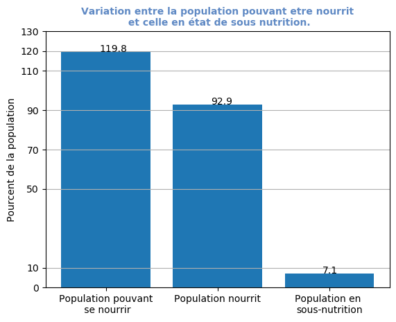

```python
fig, ax = plt.subplots()

pop = ['Population pouvant\n se nourrir', 'Population nourrit', 'Population en \nsous-nutrition']
counts = [pourcentage_pers_pouvant_etre_nourri, pop_nourri_2017, proportion_pop_2017]
bar_labels = ['pop', 'blue', 'orange']
bar_colors = ['tab:blue', 'tab:blue', 'tab:blue']

ax.bar(pop, counts, label=bar_labels, color=bar_colors)
plt.grid(axis='y')
plt.ylim(0, 110)
plt.yticks([0, 10, 50, 70, 90, 110, 120, 130])
for i in range(3):
    plt.text(i - 0.06, counts[i] , round(counts[i],1))

ax.set_ylabel('Pourcent de la population')
ax.set_title('Variation entre la population pouvant etre nourrit\n et celle en état de sous nutrition.', fontsize=10, color= '#5f89c4', fontweight='bold')

plt.show()
```

### Requete 3: disponibilité alimentaire des produits végétaux.

Retour au sommaire

#### Filtre par Origine vegetale du df `data_dispo_alimentaire` 3.1

```python
data_dispo_alimentaire_vegetale = data_dispo_alimentaire.loc[data_dispo_alimentaire['Origine'] == 'vegetale', ['Zone', 'Disponibilité alimentaire (Kcal/personne/jour)']]
data_dispo_alimentaire_vegetale.head(10)
```

|  | Zone | Disponibilité alimentaire (Kcal/personne/jour) |
| --- | --- | --- |
| 1 | Afghanistan | 1.0 |
| 2 | Afghanistan | 1.0 |
| 3 | Afghanistan | 0.0 |
| 4 | Afghanistan | 4.0 |
| 6 | Afghanistan | 0.0 |
| 7 | Afghanistan | 1369.0 |
| 8 | Afghanistan | 0.0 |
| 9 | Afghanistan | 0.0 |
| 10 | Afghanistan | 0.0 |
| 12 | Afghanistan | 0.0 |

##### Agrégation par Zone du df `dispo_alimentaire_vegetale` 3.1.1

```python
data_dispo_alimentaire_vegetale_zone = data_dispo_alimentaire_vegetale.groupby('Zone').sum()
data_dispo_alimentaire_vegetale_zone.tail()
```

| Zone | Disponibilité alimentaire (Kcal/personne/jour) |
| --- | --- |
| Émirats arabes unis | 2718.0 |
| Équateur | 1732.0 |
| États-Unis d'Amérique | 2698.0 |
| Éthiopie | 2005.0 |
| Îles Salomon | 2187.0 |

#### Merge des df `data_dispo_alimentaire_vegetale_zone` et `data_pop_zone_val_2017` 3.2

```python
df_merge_population_dispo_alimentaire_vegetale = data_dispo_alimentaire_vegetale_zone[['Disponibilité alimentaire (Kcal/personne/jour)']].merge(data_pop_zone_val_2017, how ='left', on= "Zone")
df_merge_population_dispo_alimentaire_vegetale.head()
```

|  | Zone | Disponibilité alimentaire (Kcal/personne/jour) | Valeur |
| --- | --- | --- | --- |
| 0 | Afghanistan | 1871.0 | 36296113.0 |
| 1 | Afrique du Sud | 2533.0 | 57009756.0 |
| 2 | Albanie | 2203.0 | 2884169.0 |
| 3 | Algérie | 2915.0 | 41389189.0 |
| 4 | Allemagne | 2461.0 | 82658409.0 |

##### Conaitre les valeurs non attribuées dans la merge 3.2.1

```python
df_merge_population_dispo_alimentaire_vegetale.loc[df_merge_population_dispo_alimentaire_vegetale.isnull().any(axis=1)]
```

|  | Zone | Disponibilité alimentaire (Kcal/personne/jour) | Valeur |
| --- | --- | --- | --- |
| 126 | Royaume-Uni | 2443.0 | NaN |
| 152 | Tchéquie (la) | 2418.0 | NaN |

##### Reset l'index du df `dispo alimentaire` et remplacer les deux pays par la bonne orthographe 3.2.2

```python
data_dispo_alimentaire_vegetale_zone.reset_index(inplace = True)
data_dispo_alimentaire_vegetale_zone['Zone'].replace({"Royaume-Uni": "Royaume-Uni de Grande-Bretagne et d'Irlande du Nord", "Tchéquie (la)": "Tchéquie"}, inplace=True)
```

```python
df_merge_population_dispo_alimentaire_vegetale = data_dispo_alimentaire_vegetale_zone[['Zone', 'Disponibilité alimentaire (Kcal/personne/jour)']].merge(data_pop_zone_val_2017, how ='left', on= "Zone")
df_merge_population_dispo_alimentaire_vegetale.head()
```

|  | Zone | Disponibilité alimentaire (Kcal/personne/jour) | Valeur |
| --- | --- | --- | --- |
| 0 | Afghanistan | 1871.0 | 36296113.0 |
| 1 | Afrique du Sud | 2533.0 | 57009756.0 |
| 2 | Albanie | 2203.0 | 2884169.0 |
| 3 | Algérie | 2915.0 | 41389189.0 |
| 4 | Allemagne | 2461.0 | 82658409.0 |

##### Création de la colone Disponibilité alimentaire (Kcal/jour) 3.2.3

```python
df_merge_population_dispo_alimentaire_vegetale['Disponibilité alimentaire (Kcal/jour)'] = df_merge_population_dispo_alimentaire_vegetale['Disponibilité alimentaire (Kcal/personne/jour)'] * df_merge_population_dispo_alimentaire_vegetale['Valeur']
df_merge_population_dispo_alimentaire_vegetale.head()
```

|  | Zone | Disponibilité alimentaire (Kcal/personne/jour) | Valeur | Disponibilité alimentaire (Kcal/jour) |
| --- | --- | --- | --- | --- |
| 0 | Afghanistan | 1871.0 | 36296113.0 | 6.791003e+10 |
| 1 | Afrique du Sud | 2533.0 | 57009756.0 | 1.444057e+11 |
| 2 | Albanie | 2203.0 | 2884169.0 | 6.353824e+09 |
| 3 | Algérie | 2915.0 | 41389189.0 | 1.206495e+11 |
| 4 | Allemagne | 2461.0 | 82658409.0 | 2.034223e+11 |

```python
df_merge_population_dispo_alimentaire_vegetale.loc[df_merge_population_dispo_alimentaire_vegetale.isnull().any(axis=1)]
```

|  | Zone | Disponibilité alimentaire (Kcal/personne/jour) | Valeur | Disponibilité alimentaire (Kcal/jour) |
| --- | --- | --- | --- | --- |

##### Création de la colone Population totale par pays pouvant etre nourri 3.2.4

```python
df_merge_population_dispo_alimentaire_vegetale['population totale par pays pouvant etre nourri'] = df_merge_population_dispo_alimentaire_vegetale['Disponibilité alimentaire (Kcal/jour)'] / 2400
df_merge_population_dispo_alimentaire_vegetale.head()
```

|  | Zone | Disponibilité alimentaire (Kcal/personne/jour) | Valeur | Disponibilité alimentaire (Kcal/jour) | population totale par pays pouvant etre nourri |
| --- | --- | --- | --- | --- | --- |
| 0 | Afghanistan | 1871.0 | 36296113.0 | 6.791003e+10 | 2.829584e+07 |
| 1 | Afrique du Sud | 2533.0 | 57009756.0 | 1.444057e+11 | 6.016905e+07 |
| 2 | Albanie | 2203.0 | 2884169.0 | 6.353824e+09 | 2.647427e+06 |
| 3 | Algérie | 2915.0 | 41389189.0 | 1.206495e+11 | 5.027062e+07 |
| 4 | Allemagne | 2461.0 | 82658409.0 | 2.034223e+11 | 8.475931e+07 |

#### Résultat du nombre théorique de personnes pouvant etre nourri (origine vegetale) 3.3

```python
nbr_theorique_pers_pouvant_etre_nourri = df_merge_population_dispo_alimentaire_vegetale.iloc[: , 4].sum()
print(f'Le nombre théorique de personnes qui pourraient être nourries (origine vegetale) est: {round(nbr_theorique_pers_pouvant_etre_nourri,2)}')
```

```
Le nombre théorique de personnes qui pourraient être nourries (origine vegetale) est: 7270628924.56
```

#### Conaitre les valeurs non attribuées dans la merge

```python
df_merge_population_dispo_alimentaire_vegetale.loc[df_merge_population_dispo_alimentaire_vegetale.isnull().any(axis=1)]
```

|  | Zone | Disponibilité alimentaire (Kcal/personne/jour) | Valeur | Disponibilité alimentaire (Kcal/jour) | population totale par pays pouvant etre nourri |
| --- | --- | --- | --- | --- | --- |

#### Reset l'index du df `dispo alimentaire` et remplacer les deux pays par la bonne orthographe

```python
data_dispo_alimentaire_vegetale_zone.reset_index(inplace = True)
data_dispo_alimentaire_vegetale_zone['Zone'].replace({"Royaume-Uni": "Royaume-Uni de Grande-Bretagne et d'Irlande du Nord", "Tchéquie (la)": "Tchéquie"}, inplace=True)
```

```python
df_merge_population_dispo_alimentaire_vegetale = data_dispo_alimentaire_vegetale_zone[['Zone', 'Disponibilité alimentaire (Kcal/personne/jour)']].merge(data_pop_zone_val_2017, how ='left', on= "Zone")
df_merge_population_dispo_alimentaire_vegetale.head()
```

|  | Zone | Disponibilité alimentaire (Kcal/personne/jour) | Valeur |
| --- | --- | --- | --- |
| 0 | Afghanistan | 1871.0 | 36296113.0 |
| 1 | Afrique du Sud | 2533.0 | 57009756.0 |
| 2 | Albanie | 2203.0 | 2884169.0 |
| 3 | Algérie | 2915.0 | 41389189.0 |
| 4 | Allemagne | 2461.0 | 82658409.0 |

#### Création de la colone Disponibilité alimentaire (Kcal/jour)

```python
df_merge_population_dispo_alimentaire_vegetale['Disponibilité alimentaire (Kcal/jour)'] = df_merge_population_dispo_alimentaire_vegetale['Disponibilité alimentaire (Kcal/personne/jour)'] * df_merge_population_dispo_alimentaire_vegetale['Valeur']
df_merge_population_dispo_alimentaire_vegetale.head()
```

|  | Zone | Disponibilité alimentaire (Kcal/personne/jour) | Valeur | Disponibilité alimentaire (Kcal/jour) |
| --- | --- | --- | --- | --- |
| 0 | Afghanistan | 1871.0 | 36296113.0 | 6.791003e+10 |
| 1 | Afrique du Sud | 2533.0 | 57009756.0 | 1.444057e+11 |
| 2 | Albanie | 2203.0 | 2884169.0 | 6.353824e+09 |
| 3 | Algérie | 2915.0 | 41389189.0 | 1.206495e+11 |
| 4 | Allemagne | 2461.0 | 82658409.0 | 2.034223e+11 |

```python
df_merge_population_dispo_alimentaire_vegetale.loc[df_merge_population_dispo_alimentaire_vegetale.isnull().any(axis=1)]
```

|  | Zone | Disponibilité alimentaire (Kcal/personne/jour) | Valeur | Disponibilité alimentaire (Kcal/jour) |
| --- | --- | --- | --- | --- |

#### Création de la colone Population totale par pays pouvant etre nourri

```python
df_merge_population_dispo_alimentaire_vegetale['population totale par pays pouvant etre nourri'] = df_merge_population_dispo_alimentaire_vegetale['Disponibilité alimentaire (Kcal/jour)'] / 2400
df_merge_population_dispo_alimentaire_vegetale.head()
```

|  | Zone | Disponibilité alimentaire (Kcal/personne/jour) | Valeur | Disponibilité alimentaire (Kcal/jour) | population totale par pays pouvant etre nourri |
| --- | --- | --- | --- | --- | --- |
| 0 | Afghanistan | 1871.0 | 36296113.0 | 6.791003e+10 | 2.829584e+07 |
| 1 | Afrique du Sud | 2533.0 | 57009756.0 | 1.444057e+11 | 6.016905e+07 |
| 2 | Albanie | 2203.0 | 2884169.0 | 6.353824e+09 | 2.647427e+06 |
| 3 | Algérie | 2915.0 | 41389189.0 | 1.206495e+11 | 5.027062e+07 |
| 4 | Allemagne | 2461.0 | 82658409.0 | 2.034223e+11 | 8.475931e+07 |

#### Résultat du nombre théorique de personnes pouvant etre nourri (origine vegetale)

```python
nbr_theorique_pers_pouvant_etre_nourri = df_merge_population_dispo_alimentaire_vegetale.iloc[: , 4].sum()
print(f'Le nombre théorique de personnes qui pourraient être nourries (origine vegetale) est: {round(nbr_theorique_pers_pouvant_etre_nourri,2)}')
```

```
Le nombre théorique de personnes qui pourraient être nourries (origine vegetale) est: 7270628924.56
```

```python
nombre_total_pers_mondial_produit_vegetale = df_merge_population_dispo_alimentaire_vegetale.iloc[: , 2].sum()
pourcentage_pers_pouvant_etre_nourri_vegetale = round(nbr_theorique_pers_pouvant_etre_nourri * 100 / nombre_total_pers_mondial_produit_vegetale,2)
print(f'Le nombre théorique de personnes qui pourraient être nourries est: {pourcentage_pers_pouvant_etre_nourri_vegetale} %')
```

```
Le nombre théorique de personnes qui pourraient être nourries est: 98.66 %
```

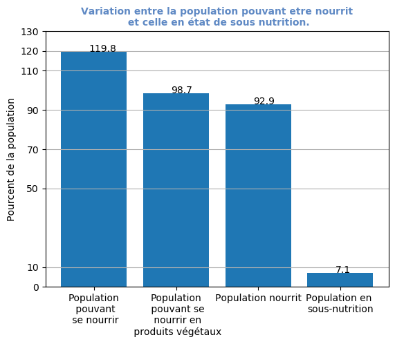

```python
fig, ax = plt.subplots()


pop = ['Population\n pouvant\n se nourrir', 'Population\n pouvant se\n nourrir en\n produits végétaux', 'Population nourrit', 'Population en \nsous-nutrition']
counts = [pourcentage_pers_pouvant_etre_nourri, pourcentage_pers_pouvant_etre_nourri_vegetale, pop_nourri_2017, proportion_pop_2017]
# bar_labels = ['pop', 'blue', 'orange']
bar_colors = ['tab:blue', 'tab:blue', 'tab:blue', 'tab:blue']

ax.bar(pop, counts, label=bar_labels, color=bar_colors)
plt.grid(axis='y')
# plt.ylim(0, 110)
plt.yticks([0, 10, 50, 70, 90, 110, 120, 130])
for i in range(4):
    plt.text(i - 0.06, counts[i] , round(counts[i],1))

ax.set_ylabel('Pourcent de la population')
ax.set_title('Variation entre la population pouvant etre nourrit\n et celle en état de sous nutrition.', fontsize=10, color= '#5f89c4', fontweight='bold')

plt.show()
```

### Requete 4: l’utilisation de la disponibilité intérieure, en particulier la part qui est attribuée à l’alimentation animale, celle qui est perdue et celle qui est concrètement utilisée pour l'alimentation humaine.

Retour au sommaire

#### Creation de la variable disponibilite intérieur totale: `disponibilite_int_totale` 4.1

```python
disponibilite_int_totale = data_dispo_alimentaire['Disponibilité intérieure'].sum()
print(f"la disponibilité intérieur totale est de: {disponibilite_int_totale}")
```

```
la disponibilité intérieur totale est de: 9848994.0
```

#### Création de la variable disponibilité alimentation animale: `disponibilite_animale` 4.2

```python
disponibilite_animale = data_dispo_alimentaire['Aliments pour animaux'].sum()
print(f"la disponibilité pour l'alimentation animale est de: {disponibilite_animale}")
```

```
la disponibilité pour l'alimentation animale est de: 1304245.0
```

#### Calcule de la part attribuée à l'alimentation animale 4.3

```python
calc_part_animale = round(disponibilite_animale * 100 / disponibilite_int_totale,2)
print(f"la part attribuée pour l'alimentation animale est de: {calc_part_animale}%")
```

```
la part attribuée pour l'alimentation animale est de: 13.24%
```

#### Calcule de la perte 4.4

##### Création de la variable `perte` 4.4.1

```python
perte = data_dispo_alimentaire['Pertes'].sum()
perte
```

```
453698.0
```

##### La part perdue 4.4.2

```python
calc_perte = round(perte * 100 / disponibilite_int_totale,2)
print(f"la part perdue est de: {calc_perte}%")
```

```
la part perdue est de: 4.61%
```

#### Calcule de la Disponibilité alimentaire pour l'alimentation humaine 4.5

##### Création de la variable disponibilité alimentation pour les humains: `dispo_alimentaire_humain` 4.5.1

```python
dispo_alimentaire_humain = data_dispo_alimentaire['Nourriture'].sum()
dispo_alimentaire_humain
```

```
4876258.0
```

##### La part attribuée au humains 4.5.2

```python
calc_part_humain = round(dispo_alimentaire_humain * 100 / disponibilite_int_totale,2)
print(f"La part attibuée pour l'alimentation humaine est de {calc_part_humain} %")
```

```
La part attibuée pour l'alimentation humaine est de 49.51 %
```

#### Calcule pour savoir si le resultat obtenue est le bon (calcule de la valeur totale) 4.6

##### Création de la variable disponibilité pour la semence: `dispo_semences` 4.6.1

```python
dispo_semences = data_dispo_alimentaire['Semences'].sum()
dispo_semences
```

```
154681.0
```

##### La part attribuée pour la semence 4.6.2

```python
calc_part_semence = round(dispo_semences * 100 / disponibilite_int_totale,2)
print(f"La part attibuée pour la semence est de {calc_part_semence} %")
```

```
La part attibuée pour la semence est de 1.57 %
```

##### Calcule de la part attribuée aux traitements 4.6.3

###### Création de la variable disponibilité pour le traitement: `dispo_traitement` 4.6.4

```python
dispo_traitement = data_dispo_alimentaire['Traitement'].sum()
dispo_traitement
```

```
2204687.0
```

###### La part attribuée pour la traitement 4.6.5

```python
calc_part_traitement = round(dispo_traitement * 100 / disponibilite_int_totale,2)
print(f"La part attibuée pour le traitement est de {calc_part_traitement} %")
```

```
La part attibuée pour le traitement est de 22.38 %
```

##### Calcule de la disponibilité des autres utilisations 4.6.6

##### Création de la variable disponibilité pour les autres utilisations: `dispo_autre_utilisation` 4.6.7

```python
dispo_autre_utilisation = data_dispo_alimentaire['Autres Utilisations'].sum()
dispo_autre_utilisation
```

```
865023.0
```

##### La part attribuée pour les autres utilisations 4.6.8

```python
calc_part_autre_utilisation = round(dispo_autre_utilisation * 100 / disponibilite_int_totale,2)
print(f"La part attibuée pour lees autres utilisation est de {calc_part_autre_utilisation} %")
```

```
La part attibuée pour lees autres utilisation est de 8.78 %
```

##### Calcule de la disponibilité totale 4.6.9

```python
calc_utilisation_total = round(calc_part_animale + calc_perte + calc_part_humain + calc_part_semence + calc_part_traitement + calc_part_autre_utilisation,1)
print(f"La disponibilité totale est de: {calc_utilisation_total} % \nNous avons bien le bon resultat car nous trouvons 100% de la disponibilité totale.")
```

```
La disponibilité totale est de: 100.1 %
Nous avons bien le bon resultat car nous trouvons 100% de la disponibilité totale.
```

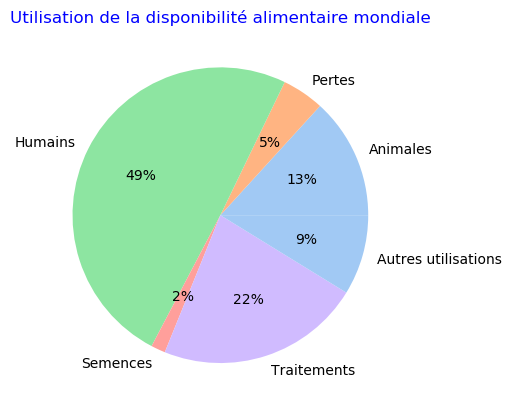

```python
#define data
data = [calc_part_animale, calc_perte, calc_part_humain, calc_part_semence, calc_part_traitement, calc_part_autre_utilisation]
labels = ['Animales', 'Pertes', 'Humains', 'Semences', 'Traitements', 'Autres utilisations']

#define Seaborn color palette to use
colors = sns.color_palette('pastel')[0:5]

#create pie chart
plt.pie(data, labels = labels, colors = colors, autopct='%.0f%%')
plt.title("Utilisation de la disponibilité alimentaire mondiale",color='b')

plt.show()
```

### Les pays pour lesquels la proportion de personnes sous-alimentées est la plus forte en 2017

Retour au sommaire

#### Nettoyage des données. 5.1

```python
sn_2017 = pd.merge(data_pop_zone_val_2017, data_sn_zone_val_2017, on='Zone',how='right')
sn_2017.head()
```

|  | Zone | Valeur_x | Valeur_y |
| --- | --- | --- | --- |
| 0 | Afghanistan | 36296113.0 | 10500000.0 |
| 1 | Afrique du Sud | 57009756.0 | 3100000.0 |
| 2 | Albanie | 2884169.0 | 100000.0 |
| 3 | Algérie | 41389189.0 | 1300000.0 |
| 4 | Allemagne | 82658409.0 | NaN |

```python
donnee_manquante_sn_2017 = sn_2017.loc[sn_2017.isnull().any(axis=1)].shape[0]
print(f'Nous avons {donnee_manquante_sn_2017} données manquantes ')
```

```
Nous avons 119 données manquantes
```

#### Création de la colone Proportion (%) qui corresponf à la proportion de personnes sous-alimentées dans leur pays respestif. 5.2

```python
sn_2017['Proportion (%)'] = round(sn_2017['Valeur_y']*100 / sn_2017['Valeur_x'], 2)
sn_2017.head(3)
```

|  | Zone | Valeur_x | Valeur_y | Proportion (%) |
| --- | --- | --- | --- | --- |
| 0 | Afghanistan | 36296113.0 | 10500000.0 | 28.93 |
| 1 | Afrique du Sud | 57009756.0 | 3100000.0 | 5.44 |
| 2 | Albanie | 2884169.0 | 100000.0 | 3.47 |

#### Resultat des pays où la sous-alimentation est la plus forte en 2017. 5.3

```python
sn_2017_ascending = sn_2017.sort_values(by='Proportion (%)', ascending=False).head(10)
```

```python
#find_substring_on_table(sn_2017, 'thi')
```

```python
cm = sns.light_palette("blue", as_cmap=True)

s = sn_2017_ascending.style.background_gradient(cmap=cm)
s
```

|  | Zone | Valeur_x | Valeur_y | Proportion (%) |
| --- | --- | --- | --- | --- |
| 78 | Haïti | 10982366.000000 | 5300000.000000 | 48.260000 |
| 157 | République populaire démocratique de Corée | 25429825.000000 | 12000000.000000 | 47.190000 |
| 108 | Madagascar | 25570512.000000 | 10500000.000000 | 41.060000 |
| 103 | Libéria | 4702226.000000 | 1800000.000000 | 38.280000 |
| 100 | Lesotho | 2091534.000000 | 800000.000000 | 38.250000 |
| 183 | Tchad | 15016753.000000 | 5700000.000000 | 37.960000 |
| 161 | Rwanda | 11980961.000000 | 4200000.000000 | 35.060000 |
| 121 | Mozambique | 28649018.000000 | 9400000.000000 | 32.810000 |
| 186 | Timor-Leste | 1243258.000000 | 400000.000000 | 32.170000 |
| 0 | Afghanistan | 36296113.000000 | 10500000.000000 | 28.930000 |

### Les 10 pays qui ont le plus bénéficiés d’aide depuis 2013.

Retour au sommaire

```python
data_aide_alimentaire = pd.read_csv('aide_alimentaire.csv')
data_aide_alimentaire.head()
```

|  | Pays bénéficiaire | Année | Produit | Valeur |
| --- | --- | --- | --- | --- |
| 0 | Afghanistan | 2013 | Autres non-céréales | 682 |
| 1 | Afghanistan | 2014 | Autres non-céréales | 335 |
| 2 | Afghanistan | 2013 | Blé et Farin | 39224 |
| 3 | Afghanistan | 2014 | Blé et Farin | 15160 |
| 4 | Afghanistan | 2013 | Céréales | 40504 |

```python
donnee_manquante = data_aide_alimentaire.loc[data_aide_alimentaire.isnull().any(axis=1)].shape[0]
print(f'Nous avons auccune données maquantes:  \n{donnee_manquante}')
```

```
Nous avons auccune données maquantes:
0
```

```python
data_aide_alimentaire_since_2013 = data_aide_alimentaire[data_aide_alimentaire['Année']>=2013].groupby('Pays bénéficiaire').sum()
data_aide_alimentaire_since_2013.head()
```

| Pays bénéficiaire | Année | Valeur |
| --- | --- | --- |
| Afghanistan | 32216 | 185452 |
| Algérie | 78561 | 81114 |
| Angola | 8054 | 5014 |
| Bangladesh | 50347 | 348188 |
| Bhoutan | 24170 | 2666 |

```python
rank_aide_alimentaire = data_aide_alimentaire_since_2013['Valeur'].sort_values(ascending=False)
df_rank_aide_alimentaire = rank_aide_alimentaire.to_frame().head(10)
```

```python
cms = sns.light_palette("blue", as_cmap=True)

so = df_rank_aide_alimentaire.style.background_gradient(cmap=cms)
so
```

| Pays bénéficiaire | Valeur |
| --- | --- |
| République arabe syrienne | 1858943 |
| Éthiopie | 1381294 |
| Yémen | 1206484 |
| Soudan du Sud | 695248 |
| Soudan | 669784 |
| Kenya | 552836 |
| Bangladesh | 348188 |
| Somalie | 292678 |
| République démocratique du Congo | 288502 |
| Niger | 276344 |

### Les pays ayant le plus/moins de disponibilité alimentaire.

Retour au sommaire

```python
zone_data_alimentaire.sort_values(by='Disponibilité alimentaire (Kcal/personne/jour)', ascending=False).head(10)
```

|  | Zone | Aliments pour animaux | Autres Utilisations | Disponibilité alimentaire (Kcal/personne/jour) | Disponibilité alimentaire en quantité (kg/personne/an) | Disponibilité de matière grasse en quantité (g/personne/jour) | Disponibilité de protéines en quantité (g/personne/jour) | Disponibilité intérieure | Exportations - Quantité | Importations - Quantité | Nourriture | Pertes | Production | Semences | Traitement | Variation de stock |
| --- | --- | --- | --- | --- | --- | --- | --- | --- | --- | --- | --- | --- | --- | --- | --- | --- |
| 11 | Autriche | 3412.0 | 1001.0 | 3770.0 | 1069.20 | 170.44 | 106.20 | 19308.0 | 6733.0 | 8463.0 | 9085.0 | 459.0 | 18129.0 | 173.0 | 5178.0 | -556.0 |
| 16 | Belgique | 5533.0 | 3226.0 | 3737.0 | 1002.09 | 161.95 | 99.37 | 29358.0 | 30345.0 | 35276.0 | 11134.0 | 564.0 | 24496.0 | 153.0 | 8960.0 | -64.0 |
| 159 | Turquie | 17750.0 | 3006.0 | 3708.0 | 968.15 | 119.64 | 108.12 | 131377.0 | 14593.0 | 12136.0 | 72551.0 | 12036.0 | 137432.0 | 2553.0 | 23560.0 | -3599.0 |
| 171 | États-Unis d'Amérique | 148432.0 | 154699.0 | 3682.0 | 1002.39 | 161.37 | 109.42 | 777992.0 | 163524.0 | 81887.0 | 320889.0 | 7162.0 | 894668.0 | 10403.0 | 141010.0 | -35032.0 |
| 74 | Israël | 2525.0 | 801.0 | 3610.0 | 922.14 | 151.39 | 128.00 | 11267.0 | 1648.0 | 5883.0 | 7132.0 | 220.0 | 6906.0 | 71.0 | 564.0 | 128.0 |
| 72 | Irlande | 3758.0 | 1120.0 | 3602.0 | 1150.15 | 125.69 | 109.91 | 10738.0 | 6828.0 | 6254.0 | 5320.0 | 236.0 | 11501.0 | 89.0 | 399.0 | -192.0 |
| 75 | Italie | 16144.0 | 3228.0 | 3578.0 | 993.20 | 154.69 | 108.49 | 97405.0 | 23643.0 | 38692.0 | 60584.0 | 1861.0 | 80855.0 | 736.0 | 14870.0 | 1496.0 |
| 89 | Luxembourg | 147.0 | 11.0 | 3540.0 | 1150.66 | 141.49 | 113.64 | 802.0 | 821.0 | 1076.0 | 607.0 | 11.0 | 593.0 | 9.0 | 24.0 | -41.0 |
| 168 | Égypte | 15084.0 | 2262.0 | 3518.0 | 803.79 | 63.09 | 103.22 | 115133.0 | 5014.0 | 24100.0 | 65957.0 | 7608.0 | 95848.0 | 1365.0 | 22924.0 | 199.0 |
| 4 | Allemagne | 30209.0 | 7711.0 | 3503.0 | 957.52 | 141.62 | 101.39 | 162275.0 | 57431.0 | 65353.0 | 79238.0 | 3781.0 | 154547.0 | 1551.0 | 39842.0 | -192.0 |

```python
#pays_plus_dispo_alimentaire = zone_data_alimentaire.loc[zone_data_alimentaire.index[11],'Zone']
#print(f"Le pays ayant le plus de Diponibilité alimentaire est l'{pays_plus_dispo_alimentaire}")
```

```python
zone_data_alimentaire.sort_values(by='Disponibilité alimentaire (Kcal/personne/jour)', ascending=True).head(10)
```

|  | Zone | Aliments pour animaux | Autres Utilisations | Disponibilité alimentaire (Kcal/personne/jour) | Disponibilité alimentaire en quantité (kg/personne/an) | Disponibilité de matière grasse en quantité (g/personne/jour) | Disponibilité de protéines en quantité (g/personne/jour) | Disponibilité intérieure | Exportations - Quantité | Importations - Quantité | Nourriture | Pertes | Production | Semences | Traitement | Variation de stock |
| --- | --- | --- | --- | --- | --- | --- | --- | --- | --- | --- | --- | --- | --- | --- | --- | --- |
| 128 | République centrafricaine | 1.0 | 27.0 | 1879.0 | 453.73 | 59.41 | 46.04 | 2582.0 | 0.0 | 76.0 | 2092.0 | 122.0 | 2503.0 | 63.0 | 278.0 | 3.0 |
| 166 | Zambie | 408.0 | 69.0 | 1924.0 | 350.12 | 42.05 | 55.22 | 10041.0 | 675.0 | 380.0 | 5088.0 | 242.0 | 10526.0 | 76.0 | 4178.0 | -182.0 |
| 91 | Madagascar | 842.0 | 2522.0 | 2056.0 | 425.07 | 24.49 | 46.69 | 15216.0 | 236.0 | 924.0 | 9741.0 | 966.0 | 14160.0 | 375.0 | 844.0 | 375.0 |
| 0 | Afghanistan | 768.0 | 415.0 | 2087.0 | 351.41 | 33.50 | 58.26 | 13515.0 | 278.0 | 2988.0 | 10735.0 | 1135.0 | 11171.0 | 395.0 | 63.0 | -368.0 |
| 65 | Haïti | 481.0 | 115.0 | 2089.0 | 397.78 | 48.92 | 47.70 | 6175.0 | 15.0 | 1204.0 | 4101.0 | 679.0 | 5072.0 | 36.0 | 762.0 | -77.0 |
| 133 | République populaire démocratique de Corée | 816.0 | 695.0 | 2093.0 | 458.93 | 36.41 | 54.99 | 14876.0 | 83.0 | 993.0 | 11425.0 | 1066.0 | 13883.0 | 194.0 | 678.0 | 84.0 |
| 151 | Tchad | 104.0 | 2.0 | 2109.0 | 319.45 | 47.10 | 62.75 | 5304.0 | 0.0 | 290.0 | 4097.0 | 459.0 | 5153.0 | 101.0 | 542.0 | -141.0 |
| 167 | Zimbabwe | 131.0 | 23.0 | 2113.0 | 336.59 | 57.18 | 48.32 | 9507.0 | 278.0 | 1342.0 | 4762.0 | 188.0 | 7914.0 | 76.0 | 4330.0 | 531.0 |
| 114 | Ouganda | 348.0 | 68.0 | 2126.0 | 535.58 | 46.57 | 52.64 | 26624.0 | 1218.0 | 1257.0 | 20121.0 | 991.0 | 26321.0 | 154.0 | 4982.0 | 269.0 |
| 154 | Timor-Leste | 9.0 | 2.0 | 2129.0 | 369.10 | 51.08 | 57.51 | 447.0 | 23.0 | 100.0 | 419.0 | 14.0 | 371.0 | 2.0 | 3.0 | 2.0 |

### Question de Julien.

Retour au sommaire

#### Logique entre l’ensemble des 10 variables. 9.1

Ces variables sont toutes exprimées en milliers de tonnes

##### Vérification de l'équation 9.1.1

```python
#zone_data_alimentaire['Zone'].str.contains('Éth').any()
```

```python
#table[col].str.normalize('NFKD').str.encode('ascii', errors='ignore').str.decode('utf-8').to_frame()
```

```python
find_substring_on_table(zone_data_alimentaire, 'fr')
```

|  | Zone | Aliments pour animaux | Autres Utilisations | Disponibilité alimentaire (Kcal/personne/jour) | Disponibilité alimentaire en quantité (kg/personne/an) | Disponibilité de matière grasse en quantité (g/personne/jour) | Disponibilité de protéines en quantité (g/personne/jour) | Disponibilité intérieure | Exportations - Quantité | Importations - Quantité | Nourriture | Pertes | Production | Semences | Traitement | Variation de stock |
| --- | --- | --- | --- | --- | --- | --- | --- | --- | --- | --- | --- | --- | --- | --- | --- | --- |
| 1 | Afrique du Sud | 5309.0 | 876.0 | 3020.0 | 564.80 | 83.58 | 85.33 | 61256.0 | 11674.0 | 7517.0 | 29812.0 | 2193.0 | 63263.0 | 253.0 | 22819.0 | 2153.0 |
| 53 | France | 22769.0 | 14405.0 | 3482.0 | 937.43 | 159.15 | 110.50 | 146905.0 | 65945.0 | 33769.0 | 60272.0 | 3261.0 | 178136.0 | 1648.0 | 44966.0 | 944.0 |
| 122 | Polynésie française | 4.0 | 44.0 | 2923.0 | 735.66 | 126.09 | 97.27 | 335.0 | 10.0 | 176.0 | 202.0 | 3.0 | 159.0 | 0.0 | 76.0 | 9.0 |
| 128 | République centrafricaine | 1.0 | 27.0 | 1879.0 | 453.73 | 59.41 | 46.04 | 2582.0 | 0.0 | 76.0 | 2092.0 | 122.0 | 2503.0 | 63.0 | 278.0 | 3.0 |

```python
zone_data_alimentaire_pays = zone_data_alimentaire.iloc[[3]]
zone_data_alimentaire_pays
```

|  | Zone | Aliments pour animaux | Autres Utilisations | Disponibilité alimentaire (Kcal/personne/jour) | Disponibilité alimentaire en quantité (kg/personne/an) | Disponibilité de matière grasse en quantité (g/personne/jour) | Disponibilité de protéines en quantité (g/personne/jour) | Disponibilité intérieure | Exportations - Quantité | Importations - Quantité | Nourriture | Pertes | Production | Semences | Traitement | Variation de stock |
| --- | --- | --- | --- | --- | --- | --- | --- | --- | --- | --- | --- | --- | --- | --- | --- | --- |
| 3 | Algérie | 4352.0 | 1707.0 | 3293.0 | 809.13 | 76.48 | 91.92 | 42630.0 | 655.0 | 17403.0 | 31729.0 | 3753.0 | 26359.0 | 449.0 | 637.0 | -479.0 |

```python
relation_1_dispo_interieur = (zone_data_alimentaire_pays['Production'] + zone_data_alimentaire_pays['Importations - Quantité'] - zone_data_alimentaire_pays['Exportations - Quantité']) +\
zone_data_alimentaire_pays['Variation de stock']
relation_1_dispo_interieur
```

```
3    42628.0
dtype: float64
```

```python
relation_2_dispo_interieur = zone_data_alimentaire_pays['Aliments pour animaux'] + zone_data_alimentaire_pays['Autres Utilisations'] + zone_data_alimentaire_pays['Nourriture'] +\
zone_data_alimentaire_pays['Pertes'] + zone_data_alimentaire_pays['Semences'] + zone_data_alimentaire_pays['Traitement']
relation_2_dispo_interieur
```

```
3    42627.0
dtype: float64
```

```python
zone_data_alimentaire_pays['Disponibilité intérieure']
```

```
3    42630.0
Name: Disponibilité intérieure, dtype: float64
```

#### Chiffres intéressants sur l’utilisation des céréales, notamment la répartition entre l’alimentation humaine (colonne Nourriture) et l’alimentation pour animaux(pour l'année 2017). 9.2

##### Créatin du dataframe bilans alimentaires pour les céréales: `data_cereales_2017`. 9.2.1

```python
df_data_cereales_2017 = pd.read_csv('FAOSTAT_data_fr_10-18-2022.csv')
df_data_cereales_2017.head(10)
```

|  | Code Domaine | Domaine | Code zone (M49) | Zone | Code Élément | Élément | Code Produit (CPC) | Produit | Code année | Année | Unité | Valeur | Symbole | Description du Symbole |
| --- | --- | --- | --- | --- | --- | --- | --- | --- | --- | --- | --- | --- | --- | --- |
| 0 | SCL | Compte Disponibilités et Utilisations (CDU) | 4 | Afghanistan | 5520 | Aliments pour animaux | F1716 | Céréales | 2017 | 2017 | tonnes | 913955 | I | Valeur imputée |
| 1 | SCL | Compte Disponibilités et Utilisations (CDU) | 4 | Afghanistan | 5141 | Disponibilité alimentaire en quantité (tonnes) | F1716 | Céréales | 2017 | 2017 | tonnes | 5811099 | I | Valeur imputée |
| 2 | SCL | Compte Disponibilités et Utilisations (CDU) | 710 | Afrique du Sud | 5520 | Aliments pour animaux | F1716 | Céréales | 2017 | 2017 | tonnes | 6631754 | I | Valeur imputée |
| 3 | SCL | Compte Disponibilités et Utilisations (CDU) | 710 | Afrique du Sud | 5141 | Disponibilité alimentaire en quantité (tonnes) | F1716 | Céréales | 2017 | 2017 | tonnes | 8154940 | I | Valeur imputée |
| 4 | SCL | Compte Disponibilités et Utilisations (CDU) | 8 | Albanie | 5520 | Aliments pour animaux | F1716 | Céréales | 2017 | 2017 | tonnes | 535826 | I | Valeur imputée |
| 5 | SCL | Compte Disponibilités et Utilisations (CDU) | 8 | Albanie | 5141 | Disponibilité alimentaire en quantité (tonnes) | F1716 | Céréales | 2017 | 2017 | tonnes | 322322 | I | Valeur imputée |
| 6 | SCL | Compte Disponibilités et Utilisations (CDU) | 12 | Algérie | 5520 | Aliments pour animaux | F1716 | Céréales | 2017 | 2017 | tonnes | 6476029 | I | Valeur imputée |
| 7 | SCL | Compte Disponibilités et Utilisations (CDU) | 12 | Algérie | 5141 | Disponibilité alimentaire en quantité (tonnes) | F1716 | Céréales | 2017 | 2017 | tonnes | 6436481 | I | Valeur imputée |
| 8 | SCL | Compte Disponibilités et Utilisations (CDU) | 276 | Allemagne | 5520 | Aliments pour animaux | F1716 | Céréales | 2017 | 2017 | tonnes | 27415610 | I | Valeur imputée |
| 9 | SCL | Compte Disponibilités et Utilisations (CDU) | 276 | Allemagne | 5141 | Disponibilité alimentaire en quantité (tonnes) | F1716 | Céréales | 2017 | 2017 | tonnes | 7544615 | I | Valeur imputée |

```python
df_data_cereales_2017 = df_data_cereales_2017[['Zone', 'Élément', 'Valeur']]
df_data_cereales_2017.head(10)
```

|  | Zone | Élément | Valeur |
| --- | --- | --- | --- |
| 0 | Afghanistan | Aliments pour animaux | 913955 |
| 1 | Afghanistan | Disponibilité alimentaire en quantité (tonnes) | 5811099 |
| 2 | Afrique du Sud | Aliments pour animaux | 6631754 |
| 3 | Afrique du Sud | Disponibilité alimentaire en quantité (tonnes) | 8154940 |
| 4 | Albanie | Aliments pour animaux | 535826 |
| 5 | Albanie | Disponibilité alimentaire en quantité (tonnes) | 322322 |
| 6 | Algérie | Aliments pour animaux | 6476029 |
| 7 | Algérie | Disponibilité alimentaire en quantité (tonnes) | 6436481 |
| 8 | Allemagne | Aliments pour animaux | 27415610 |
| 9 | Allemagne | Disponibilité alimentaire en quantité (tonnes) | 7544615 |

**Nous allons prendre comme exemple 2 pays où la sous-nutrition est très faible (Allemagne, France) et à l'inverse 2 pays où la sous-nutrition est très élévé (Haiti, Libéria)et on va les comparer**

```python
df_data_2017_cereales_allemagne = df_data_cereales_2017.loc[df_data_cereales_2017['Zone'] == 'Allemagne', ['Élément', 'Valeur']]
df_data_2017_cereales_allemagne.head(10)
```

|  | Élément | Valeur |
| --- | --- | --- |
| 8 | Aliments pour animaux | 27415610 |
| 9 | Disponibilité alimentaire en quantité (tonnes) | 7544615 |

```python
df_data_2017_cereales_france = df_data_cereales_2017.loc[df_data_cereales_2017['Zone'] == 'France', ['Élément', 'Valeur']]
df_data_2017_cereales_france.head(10)
```

|  | Élément | Valeur |
| --- | --- | --- |
| 118 | Aliments pour animaux | 20061535 |
| 119 | Disponibilité alimentaire en quantité (tonnes) | 7400378 |

```python
df_data_2017_cereales_haiti = df_data_cereales_2017.loc[df_data_cereales_2017['Zone'] == 'Haïti' , ['Élément', 'Valeur']]
df_data_2017_cereales_haiti.head(10)
```

|  | Élément | Valeur |
| --- | --- | --- |
| 140 | Aliments pour animaux | 254507 |
| 141 | Disponibilité alimentaire en quantité (tonnes) | 1115182 |

```python
df_data_2017_cereales_liberia = df_data_cereales_2017.loc[df_data_cereales_2017['Zone'] == 'Libéria' , ['Élément', 'Valeur']]
df_data_2017_cereales_liberia.head(10)
```

|  | Élément | Valeur |
| --- | --- | --- |
| 186 | Aliments pour animaux | 27319 |
| 187 | Disponibilité alimentaire en quantité (tonnes) | 544571 |

##### Répartition des céréales entre l'alimentation pour les humains et celle pour les animaux. 9.2.2

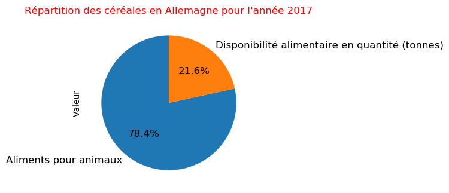

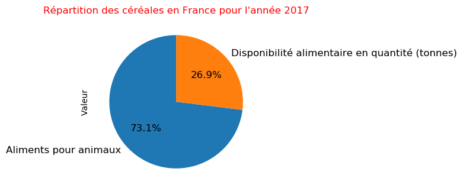

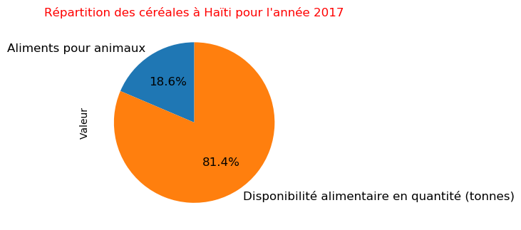

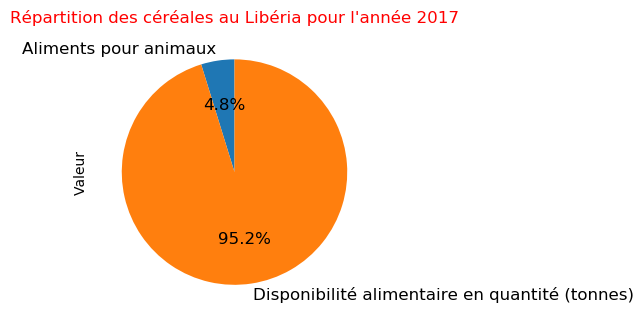

```python
plt.figure(figsize=(8,8))

# plot chart
ax1 = plt.subplot(121, aspect='equal')
df_data_2017_cereales_allemagne.plot(kind='pie', y = 'Valeur', ax=ax1, autopct='%1.1f%%',
 startangle=90, shadow=False, labels=df_data_2017_cereales_allemagne['Élément'], legend = False, fontsize=12)
# Title
plt.title("Répartition des céréales en Allemagne pour l'année 2017",color='r')
# plotting function here, e.g. plt.hist()
plt.savefig('allemagne')


plt.figure(figsize=(8,8))
ax1 = plt.subplot(121, aspect='equal')
df_data_2017_cereales_france.plot(kind='pie', y = 'Valeur', ax=ax1, autopct='%1.1f%%',
 startangle=90, shadow=False, labels=df_data_2017_cereales_france['Élément'], legend = False, fontsize=12)
plt.title("Répartition des céréales en France pour l'année 2017",color='r')
plt.savefig('france')

plt.figure(figsize=(8,8))
ax1 = plt.subplot(121, aspect='equal')
df_data_2017_cereales_haiti.plot(kind='pie', y = 'Valeur', ax=ax1, autopct='%1.1f%%',
 startangle=90, shadow=False, labels=df_data_2017_cereales_haiti['Élément'], legend = False, fontsize=12)
plt.title("Répartition des céréales à Haïti pour l'année 2017",color='r')
plt.savefig('haiti')

plt.figure(figsize=(8,8))
ax1 = plt.subplot(121, aspect='equal')
df_data_2017_cereales_liberia.plot(kind='pie', y = 'Valeur', ax=ax1, autopct='%1.1f%%',
 startangle=90, shadow=False, labels=df_data_2017_cereales_liberia['Élément'], legend = False, fontsize=12)
plt.title("Répartition des céréales au Libéria pour l'année 2017",color='r')
plt.savefig('Libéria')

plt.show()
```

##### **Conclusion** 9.2.3

Nous pouvons voir que pour les deux pays où la sous-nutrition est très faible, les céréales sont surtout utilisés pour nourrir les animaux alors que pour les deux pays qui sont en état de sous-nutritions très élevé, l'utilisation des céréales sont essentiellement pour l'alimentation humaine. D'après une étude, le blé constitue une céréale très peu chère. En Côte d’Ivoire par exemple, on estime qu’il est 25% moins cher que la semoule de manioc. D’autre part, la farine de blé étant facile à travailler, celle-ci facilite la fabrication de pain qui est très apprécié par la population locale, notamment les jeunes et les citadins. Au Sénégal, on estime ainsi à plus de 8 millions les baguettes de pain consommées par jour, soit une évolution de la consommation moyenne de pain par tête de 22 kg en 2000 à 32 kg en 2016 (source : Jacques Berthelot, SOL).

De l'autre coté : La France, 3e producteur européen d’aliments pour animaux

Pour la campagne 2020/2021, plus de 9 millions de tonnes de céréales ont été utilisées par l’industrie de l’alimentation animale, ce qui en fait la première utilisatrice de céréales en grains. Ce secteur consomme également la plupart des coproduits de transformation des céréales. Une partie de la production de céréales grains est également consommée directement à la ferme. D’autre part, 1,4 millions d’hectares de maïs fourrage et ensilage (récolté vert, plante entière) ont été cultivés en 2021, pour alimenter les élevages de ruminants. Les pailles de céréales sont également utilisées pour compléter le fourrage et ce, particulièrement en période de sècheresse où les prairies produisent moins.

### Bonus

Retour au sommaire

#### Aide alimentaire en 2016

```python
data_aide_alimentaire_since_2016 = data_aide_alimentaire[data_aide_alimentaire['Année']>=2016].groupby('Pays bénéficiaire').sum()
data_aide_alimentaire_since_2016.head()
```

| Pays bénéficiaire | Année | Valeur |
| --- | --- | --- |
| Algérie | 16128 | 9476 |
| Bhoutan | 4032 | 218 |
| Burkina Faso | 4032 | 72 |
| Bénin | 4032 | 144 |
| Cameroun | 4032 | 578 |

```python
rank_aide_alimentaire_2016 = data_aide_alimentaire_since_2016['Valeur'].sort_values(ascending=False)
df_rank_aide_alimentaire_2016 = rank_aide_alimentaire_2016.to_frame().head(10)
print(f'Les pays ayant le plus bénéficié d’aide depuis 2016 sont: \n { df_rank_aide_alimentaire_2016}')
```

```
Les pays ayant le plus bénéficié d’aide depuis 2016 sont:
                            Valeur
Pays bénéficiaire
Yémen                      465574
République arabe syrienne  118558
Niger                       92742
Haïti                       12462
Algérie                      9476
Côte d'Ivoire                8786
Colombie                     5466
Honduras                     4492
Libye                        4414
Népal                        3484
```

#### La population mondiale concidérée comme etant en sous nutrition en 2015

```python
data_pop_zone_val_2015 = data_population.loc[data_population['Année'] == 2015, ['Zone', 'Valeur']]
data_pop_zone_val_2015.head()
```

|  | Zone | Valeur |
| --- | --- | --- |
| 2 | Afghanistan | 34413.603 |
| 8 | Afrique du Sud | 55386.367 |
| 14 | Albanie | 2890.513 |
| 20 | Algérie | 39728.025 |
| 26 | Allemagne | 81787.411 |

```python
data_pop_zone_val_2015['Valeur'] = data_population.iloc[: , 2].mul(1000)
data_pop_zone_val_2015.head()
```

|  | Zone | Valeur |
| --- | --- | --- |
| 2 | Afghanistan | 34413603.0 |
| 8 | Afrique du Sud | 55386367.0 |
| 14 | Albanie | 2890513.0 |
| 20 | Algérie | 39728025.0 |
| 26 | Allemagne | 81787411.0 |

```python
data_sn_zone_val_2015 = data_sn.loc[data_sn['Année'] == '2014-2016', ['Zone', 'Valeur']]
data_sn_zone_val_2015.head(10)
```

|  | Zone | Valeur |
| --- | --- | --- |
| 2 | Afghanistan | 8.9 |
| 8 | Afrique du Sud | 2.8 |
| 14 | Albanie | 0.1 |
| 20 | Algérie | 1.3 |
| 26 | Allemagne | NaN |
| 32 | Andorre | NaN |
| 38 | Angola | 5.3 |
| 44 | Antigua-et-Barbuda | NaN |
| 50 | Arabie saoudite | 1.5 |
| 56 | Argentine | 1.1 |

```python
data_sn_zone_val_2015['Valeur'] = pd.to_numeric(data_sn_zone_val_2015['Valeur'], errors='coerce')
data_sn_zone_val_2015.info()
```

```
<class 'pandas.core.frame.DataFrame'>
Int64Index: 203 entries, 2 to 1214
Data columns (total 2 columns):
 #   Column  Non-Null Count  Dtype
---  ------  --------------  -----
 0   Zone    203 non-null    object
 1   Valeur  84 non-null     float64
dtypes: float64(1), object(1)
memory usage: 4.8+ KB
```

```python
data_sn_zone_val_2015['Valeur'] = data_sn_zone_val_2015.iloc[: , 1].mul(1000000)
data_sn_zone_val_2015.head(10)
```

|  | Zone | Valeur |
| --- | --- | --- |
| 2 | Afghanistan | 8900000.0 |
| 8 | Afrique du Sud | 2800000.0 |
| 14 | Albanie | 100000.0 |
| 20 | Algérie | 1300000.0 |
| 26 | Allemagne | NaN |
| 32 | Andorre | NaN |
| 38 | Angola | 5300000.0 |
| 44 | Antigua-et-Barbuda | NaN |
| 50 | Arabie saoudite | 1500000.0 |
| 56 | Argentine | 1100000.0 |

```python
proportion_pop_2015 = ( data_sn_zone_val_2015['Valeur'].sum() * 100 ) / data_pop_zone_val_2015['Valeur'].sum()
print('Environ ' + str(round(proportion_pop_2015,3)) +  ' % de la population mondiale est concidéré comme etant en sous nutrition en 2015')
```

```
Environ 7.11 % de la population mondiale est concidéré comme etant en sous nutrition en 2015
```

#### La population mondiale concidérée comme etant en sous nutrition en 2016

```python
data_pop_zone_val_2016 = data_population.loc[data_population['Année'] == 2016, ['Zone', 'Valeur']]
data_pop_zone_val_2016.head()
```

|  | Zone | Valeur |
| --- | --- | --- |
| 3 | Afghanistan | 35383.032 |
| 9 | Afrique du Sud | 56207.646 |
| 15 | Albanie | 2886.438 |
| 21 | Algérie | 40551.392 |
| 27 | Allemagne | 82193.768 |

```python
data_pop_zone_val_2016['Valeur'] = data_population.iloc[: , 2].mul(1000)
data_pop_zone_val_2016.head()
```

|  | Zone | Valeur |
| --- | --- | --- |
| 3 | Afghanistan | 35383032.0 |
| 9 | Afrique du Sud | 56207646.0 |
| 15 | Albanie | 2886438.0 |
| 21 | Algérie | 40551392.0 |
| 27 | Allemagne | 82193768.0 |

```python
data_sn_zone_val_2016 = data_sn.loc[data_sn['Année'] == '2015-2017', ['Zone', 'Valeur']]
data_sn_zone_val_2016.head(10)
```

|  | Zone | Valeur |
| --- | --- | --- |
| 3 | Afghanistan | 9.7 |
| 9 | Afrique du Sud | 3 |
| 15 | Albanie | 0.1 |
| 21 | Algérie | 1.3 |
| 27 | Allemagne | NaN |
| 33 | Andorre | NaN |
| 39 | Angola | 5.6 |
| 45 | Antigua-et-Barbuda | NaN |
| 51 | Arabie saoudite | 1.5 |
| 57 | Argentine | 1.3 |

```python
data_sn_zone_val_2016['Valeur'] = pd.to_numeric(data_sn_zone_val_2016['Valeur'], errors='coerce')
data_sn_zone_val_2016.info()
```

```
<class 'pandas.core.frame.DataFrame'>
Int64Index: 203 entries, 3 to 1215
Data columns (total 2 columns):
 #   Column  Non-Null Count  Dtype
---  ------  --------------  -----
 0   Zone    203 non-null    object
 1   Valeur  83 non-null     float64
dtypes: float64(1), object(1)
memory usage: 4.8+ KB
```

```python
data_sn_zone_val_2016['Valeur'] = data_sn_zone_val_2016.iloc[: , 1].mul(1000000)
data_sn_zone_val_2016.head(10)
```

|  | Zone | Valeur |
| --- | --- | --- |
| 3 | Afghanistan | 9700000.0 |
| 9 | Afrique du Sud | 3000000.0 |
| 15 | Albanie | 100000.0 |
| 21 | Algérie | 1300000.0 |
| 27 | Allemagne | NaN |
| 33 | Andorre | NaN |
| 39 | Angola | 5600000.0 |
| 45 | Antigua-et-Barbuda | NaN |
| 51 | Arabie saoudite | 1500000.0 |
| 57 | Argentine | 1300000.0 |

```python
proportion_pop_2016 = ( data_sn_zone_val_2016['Valeur'].sum() * 100 ) / data_pop_zone_val_2016['Valeur'].sum()
print('Environ ' + str(round(proportion_pop_2016,3)) +  ' % de la population mondiale est concidéré comme etant en sous nutrition en 2016')
```

```
Environ 7.082 % de la population mondiale est concidéré comme etant en sous nutrition en 2016
```

#### La population mondiale concidérée comme etant en sous nutrition en 2017

```python
data_pop_zone_val_2017 = data_population.loc[data_population['Année'] == 2017, ['Zone', 'Valeur']]
data_pop_zone_val_2017.head()
```

|  | Zone | Valeur |
| --- | --- | --- |
| 4 | Afghanistan | 36296.113 |
| 10 | Afrique du Sud | 57009.756 |
| 16 | Albanie | 2884.169 |
| 22 | Algérie | 41389.189 |
| 28 | Allemagne | 82658.409 |

```python
data_pop_zone_val_2017['Valeur'] = data_population.iloc[: , 2].mul(1000)
data_pop_zone_val_2017.head()
```

|  | Zone | Valeur |
| --- | --- | --- |
| 4 | Afghanistan | 36296113.0 |
| 10 | Afrique du Sud | 57009756.0 |
| 16 | Albanie | 2884169.0 |
| 22 | Algérie | 41389189.0 |
| 28 | Allemagne | 82658409.0 |

```python
data_sn_zone_val_2017 = data_sn.loc[data_sn['Année'] == '2016-2018', ['Zone', 'Valeur']]
data_sn_zone_val_2017.head(10)
```

|  | Zone | Valeur |
| --- | --- | --- |
| 4 | Afghanistan | 10.5 |
| 10 | Afrique du Sud | 3.1 |
| 16 | Albanie | 0.1 |
| 22 | Algérie | 1.3 |
| 28 | Allemagne | NaN |
| 34 | Andorre | NaN |
| 40 | Angola | 5.8 |
| 46 | Antigua-et-Barbuda | NaN |
| 52 | Arabie saoudite | 1.6 |
| 58 | Argentine | 1.5 |

```python
data_sn_zone_val_2017['Valeur'] = pd.to_numeric(data_sn_zone_val_2017['Valeur'], errors='coerce')
data_sn_zone_val_2017.info()
```

```
<class 'pandas.core.frame.DataFrame'>
Int64Index: 203 entries, 4 to 1216
Data columns (total 2 columns):
 #   Column  Non-Null Count  Dtype
---  ------  --------------  -----
 0   Zone    203 non-null    object
 1   Valeur  84 non-null     float64
dtypes: float64(1), object(1)
memory usage: 4.8+ KB
```

```python
data_sn_zone_val_2017['Valeur'] = data_sn_zone_val_2017.iloc[: , 1].mul(1000000)
data_sn_zone_val_2017.head(10)
```

|  | Zone | Valeur |
| --- | --- | --- |
| 4 | Afghanistan | 10500000.0 |
| 10 | Afrique du Sud | 3100000.0 |
| 16 | Albanie | 100000.0 |
| 22 | Algérie | 1300000.0 |
| 28 | Allemagne | NaN |
| 34 | Andorre | NaN |
| 40 | Angola | 5800000.0 |
| 46 | Antigua-et-Barbuda | NaN |
| 52 | Arabie saoudite | 1600000.0 |
| 58 | Argentine | 1500000.0 |

```python
proportion_pop_2017 = ( data_sn_zone_val_2017['Valeur'].sum() * 100 ) / data_pop_zone_val_2017['Valeur'].sum()
print('Environ ' + str(round(proportion_pop_2017,3)) +  ' % de la population mondiale est concidéré comme etant en sous nutrition en 2017')
```

```
Environ 7.097 % de la population mondiale est concidéré comme etant en sous nutrition en 2017
```

#### La population mondiale concidérée comme etant en sous nutrition en 2018

```python
data_pop_zone_val_2018 = data_population.loc[data_population['Année'] == 2018, ['Zone', 'Valeur']]
data_pop_zone_val_2018.head()
```

|  | Zone | Valeur |
| --- | --- | --- |
| 5 | Afghanistan | 37171.921 |
| 11 | Afrique du Sud | 57792.518 |
| 17 | Albanie | 2882.740 |
| 23 | Algérie | 42228.408 |
| 29 | Allemagne | 83124.418 |

```python
data_pop_zone_val_2018['Valeur'] = data_population.iloc[: , 2].mul(1000)
data_pop_zone_val_2018.head()
```

|  | Zone | Valeur |
| --- | --- | --- |
| 5 | Afghanistan | 37171921.0 |
| 11 | Afrique du Sud | 57792518.0 |
| 17 | Albanie | 2882740.0 |
| 23 | Algérie | 42228408.0 |
| 29 | Allemagne | 83124418.0 |

```python
data_sn_zone_val_2018 = data_sn.loc[data_sn['Année'] == '2017-2019', ['Zone', 'Valeur']]
data_sn_zone_val_2018.head(10)
```

|  | Zone | Valeur |
| --- | --- | --- |
| 5 | Afghanistan | 11.1 |
| 11 | Afrique du Sud | 3.3 |
| 17 | Albanie | 0.1 |
| 23 | Algérie | 1.2 |
| 29 | Allemagne | NaN |
| 35 | Andorre | NaN |
| 41 | Angola | 5.7 |
| 47 | Antigua-et-Barbuda | NaN |
| 53 | Arabie saoudite | 1.6 |
| 59 | Argentine | 1.7 |

```python
data_sn_zone_val_2018['Valeur'] = pd.to_numeric(data_sn_zone_val_2018['Valeur'], errors='coerce')
data_sn_zone_val_2018.info()
```

```
<class 'pandas.core.frame.DataFrame'>
Int64Index: 203 entries, 5 to 1217
Data columns (total 2 columns):
 #   Column  Non-Null Count  Dtype
---  ------  --------------  -----
 0   Zone    203 non-null    object
 1   Valeur  85 non-null     float64
dtypes: float64(1), object(1)
memory usage: 4.8+ KB
```

```python
data_sn_zone_val_2018['Valeur'] = data_sn_zone_val_2018.iloc[: , 1].mul(1000000)
data_sn_zone_val_2018.head()
```

|  | Zone | Valeur |
| --- | --- | --- |
| 5 | Afghanistan | 11100000.0 |
| 11 | Afrique du Sud | 3300000.0 |
| 17 | Albanie | 100000.0 |
| 23 | Algérie | 1200000.0 |
| 29 | Allemagne | NaN |

```python
proportion_pop_2018 = ( data_sn_zone_val_2018['Valeur'].sum() * 100 ) / data_pop_zone_val_2018['Valeur'].sum()
print('Environ ' + str(round(proportion_pop_2018,3)) +  ' % de la population mondiale est concidéré comme etant en sous nutrition en 2018')
```

```
Environ 7.131 % de la population mondiale est concidéré comme etant en sous nutrition en 2018
```

#### Comparaison

```python
difference_sn_2015_2016 = round(proportion_pop_2016 - proportion_pop_2015, 3)
print(f'La population mondiale concidéré comme etant en sous nutrition à augmenté de {difference_sn_2015_2016}% entre 2015 et 2016')
```

[output not shown]

```python
difference_sn_2016_2017 = round(proportion_pop_2017 - proportion_pop_2016, 3)
print(f'La population mondiale concidéré comme etant en sous nutrition à augmenté de {difference_sn_2016_2017}% entre 2016 et 2017')
```

```
La population mondiale concidéré comme etant en sous nutrition à augmenté de 0.015% entre 2016 et 2017
```

```python
difference_sn_2017_2018 = round(proportion_pop_2018 - proportion_pop_2017, 3)
print(f'La population mondiale concidéré comme etant en sous nutrition à augmenté de {difference_sn_2017_2018}% entre 2017 et 2018')
```

```
La population mondiale concidéré comme etant en sous nutrition à augmenté de 0.034% entre 2017 et 2018
```

```python
print(proportion_pop_2015, proportion_pop_2016, proportion_pop_2017, proportion_pop_2018)
```

```
7.1096914793284585 7.081713923027183 7.097118203283074 7.131093176274328
```

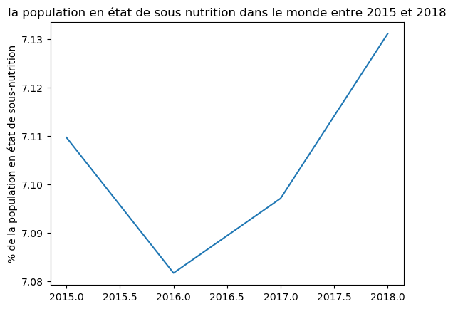

```python
# define data values
x = 2015, 2016, 2017, 2018   # X-axis points
y = proportion_pop_2015, proportion_pop_2016, proportion_pop_2017, proportion_pop_2018  # Y-axis points

#plt.xlabel("Année")  # add X-axis label
plt.ylabel("% de la population en état de sous-nutrition")  # add Y-axis label
plt.title("la population en état de sous nutrition dans le monde entre 2015 et 2018")  # add title
plt.savefig('evolution pop')

plt.plot(x, y)
plt.show()
```

```python
from IPython.display import Image
Image(url='https://lafaimexpliquee.org/La_faim_expliquee/Faits_et_chiffres_files/Figure2_22_1.jpg', width=750)
```

[figure not shown]

### Part de la disoponibilité en ethiopie

```python
find_substring_on_table(zone_data_alimentaire, 'france')
```

|  | Zone | Aliments pour animaux | Autres Utilisations | Disponibilité alimentaire (Kcal/personne/jour) | Disponibilité alimentaire en quantité (kg/personne/an) | Disponibilité de matière grasse en quantité (g/personne/jour) | Disponibilité de protéines en quantité (g/personne/jour) | Disponibilité intérieure | Exportations - Quantité | Importations - Quantité | Nourriture | Pertes | Production | Semences | Traitement | Variation de stock |
| --- | --- | --- | --- | --- | --- | --- | --- | --- | --- | --- | --- | --- | --- | --- | --- | --- |
| 53 | France | 22769.0 | 14405.0 | 3482.0 | 937.43 | 159.15 | 110.5 | 146905.0 | 65945.0 | 33769.0 | 60272.0 | 3261.0 | 178136.0 | 1648.0 | 44966.0 | 944.0 |

```python
zone_data_alimentaire_ethiopie = zone_data_alimentaire.iloc[[172]]
zone_data_alimentaire_ethiopie
```

|  | Zone | Aliments pour animaux | Autres Utilisations | Disponibilité alimentaire (Kcal/personne/jour) | Disponibilité alimentaire en quantité (kg/personne/an) | Disponibilité de matière grasse en quantité (g/personne/jour) | Disponibilité de protéines en quantité (g/personne/jour) | Disponibilité intérieure | Exportations - Quantité | Importations - Quantité | Nourriture | Pertes | Production | Semences | Traitement | Variation de stock |
| --- | --- | --- | --- | --- | --- | --- | --- | --- | --- | --- | --- | --- | --- | --- | --- | --- |
| 172 | Éthiopie | 685.0 | 3641.0 | 2129.0 | 354.55 | 25.89 | 60.39 | 44014.0 | 941.0 | 1711.0 | 33361.0 | 2256.0 | 46102.0 | 640.0 | 3443.0 | -2857.0 |

```python
disponibilite_int_totale_ethiopie = zone_data_alimentaire_ethiopie['Disponibilité intérieure'].sum()
print(f"la disponibilité intérieur totale est de: {disponibilite_int_totale_ethiopie}")
```

```
la disponibilité intérieur totale est de: 44014.0
```

```python
disponibilite_animale_ethiopie = zone_data_alimentaire_ethiopie['Aliments pour animaux'].sum()
print(f"la disponibilité pour l'alimentation animale est de: {disponibilite_animale_ethiopie}")
```

```
la disponibilité pour l'alimentation animale est de: 685.0
```

```python
calc_part_animale_ethiopie = round(disponibilite_animale_ethiopie * 100 / disponibilite_int_totale_ethiopie,2)
print(f"la part attribuée pour l'alimentation animale est de: {calc_part_animale_ethiopie}%")
```

```
la part attribuée pour l'alimentation animale est de: 1.56%
```

```python
perte_ethiopie = zone_data_alimentaire_ethiopie['Pertes'].sum()
perte_ethiopie
```

```
2256.0
```

```python
calc_perte_ethiopie = round(perte_ethiopie * 100 / disponibilite_int_totale_ethiopie,2)
print(f"la part perdue est de: {calc_perte_ethiopie}%")
```

```
la part perdue est de: 5.13%
```

```python
dispo_alimentaire_humain_ethiopie = zone_data_alimentaire_ethiopie['Nourriture'].sum()
dispo_alimentaire_humain_ethiopie
```

```
33361.0
```

```python
calc_part_humain_ethiopie = round(dispo_alimentaire_humain_ethiopie * 100 / disponibilite_int_totale_ethiopie,2)
print(f"La part attibuée pour l'alimentation humaine est de {calc_part_humain_ethiopie} %")
```

```
La part attibuée pour l'alimentation humaine est de 75.8 %
```

```python
dispo_semences_ethiopie = zone_data_alimentaire_ethiopie['Semences'].sum()
dispo_semences_ethiopie
```

```
640.0
```

```python
calc_part_semence_ethiopie = round(dispo_semences_ethiopie * 100 / disponibilite_int_totale_ethiopie,2)
print(f"La part attibuée pour la semence est de {calc_part_semence_ethiopie} %")
```

```
La part attibuée pour la semence est de 1.45 %
```

```python
dispo_traitement_ethiopie = zone_data_alimentaire_ethiopie['Traitement'].sum()
dispo_traitement_ethiopie
```

```
3443.0
```

```python
calc_part_traitement_ethiopie = round(dispo_traitement_ethiopie * 100 / disponibilite_int_totale_ethiopie,2)
print(f"La part attibuée pour le traitement est de {calc_part_traitement_ethiopie} %")
```

```
La part attibuée pour le traitement est de 7.82 %
```

```python
dispo_autre_utilisation_ethiopie = zone_data_alimentaire_ethiopie['Autres Utilisations'].sum()
dispo_autre_utilisation_ethiopie
```

```
3641.0
```

```python
calc_part_autre_utilisation_ethiopie = round(dispo_autre_utilisation_ethiopie * 100 / disponibilite_int_totale_ethiopie,2)
print(f"La part attibuée pour lees autres utilisation est de {calc_part_autre_utilisation_ethiopie} %")
```

```
La part attibuée pour lees autres utilisation est de 8.27 %
```

```python
calc_utilisation_total_ethiopie = round(calc_part_animale_ethiopie + calc_perte_ethiopie + calc_part_humain_ethiopie + calc_part_semence_ethiopie + calc_part_traitement_ethiopie + calc_part_autre_utilisation_ethiopie,1)
print(f"La disponibilité totale est de: {calc_utilisation_total_ethiopie} % \nNous avons bien le bon resultat car nous trouvons 100% de la disponibilité totale.")
```

```
La disponibilité totale est de: 100.0 %
Nous avons bien le bon resultat car nous trouvons 100% de la disponibilité totale.
```

### Part de disponibilité au Gabon

```python
zone_data_alimentaire_gabon = zone_data_alimentaire.iloc[[55]]
zone_data_alimentaire_gabon
```

|  | Zone | Aliments pour animaux | Autres Utilisations | Disponibilité alimentaire (Kcal/personne/jour) | Disponibilité alimentaire en quantité (kg/personne/an) | Disponibilité de matière grasse en quantité (g/personne/jour) | Disponibilité de protéines en quantité (g/personne/jour) | Disponibilité intérieure | Exportations - Quantité | Importations - Quantité | Nourriture | Pertes | Production | Semences | Traitement | Variation de stock |
| --- | --- | --- | --- | --- | --- | --- | --- | --- | --- | --- | --- | --- | --- | --- | --- | --- |
| 55 | Gabon | 251.0 | 47.0 | 2826.0 | 760.93 | 59.1 | 86.28 | 2047.0 | 1.0 | 561.0 | 1266.0 | 223.0 | 1521.0 | 26.0 | 233.0 | -32.0 |

```python
disponibilite_int_totale_gabon = zone_data_alimentaire_gabon['Disponibilité intérieure'].sum()
print(f"la disponibilité intérieur totale est de: {disponibilite_int_totale_gabon}")
```

```
la disponibilité intérieur totale est de: 2047.0
```

```python
disponibilite_animale_gabon = zone_data_alimentaire_gabon['Aliments pour animaux'].sum()
print(f"la disponibilité pour l'alimentation animale est de: {disponibilite_animale_gabon}")
```

```
la disponibilité pour l'alimentation animale est de: 251.0
```

```python
calc_part_animale_gabon = round(disponibilite_animale_gabon * 100 / disponibilite_int_totale_gabon,2)
print(f"la part attribuée pour l'alimentation animale est de: {calc_part_animale_gabon}%")
```

```
la part attribuée pour l'alimentation animale est de: 12.26%
```

```python
perte_gabon = zone_data_alimentaire_gabon['Pertes'].sum()
perte_gabon
```

```
223.0
```

```python
calc_perte_gabon = round(perte_gabon * 100 / disponibilite_int_totale_gabon,2)
print(f"la part prdue est de: {calc_perte_gabon}%")
```

```
la part prdue est de: 10.89%
```

```python
dispo_alimentaire_humain_gabon = zone_data_alimentaire_gabon['Nourriture'].sum()
dispo_alimentaire_humain_gabon
```

```
1266.0
```

```python
calc_part_humain_gabon = round(dispo_alimentaire_humain_gabon * 100 / disponibilite_int_totale_gabon,2)
print(f"La part attibuée pour l'alimentation humaine est de {calc_part_humain_gabon} %")
```

```
La part attibuée pour l'alimentation humaine est de 61.85 %
```

```python
dispo_semences_gabon = zone_data_alimentaire_gabon['Semences'].sum()
dispo_semences_gabon
```

```
26.0
```

```python
calc_part_semence_gabon = round(dispo_semences_gabon * 100 / disponibilite_int_totale_gabon,2)
print(f"La part attibuée pour la semence est de {calc_part_semence_gabon} %")
```

```
La part attibuée pour la semence est de 1.27 %
```

```python
dispo_traitement_gabon = zone_data_alimentaire_gabon['Traitement'].sum()
dispo_traitement_gabon
```

```
233.0
```

```python
calc_part_traitement_gabon = round(dispo_traitement_gabon * 100 / disponibilite_int_totale_gabon,2)
print(f"La part attibuée pour le traitement est de {calc_part_traitement_gabon} %")
```

```
La part attibuée pour le traitement est de 11.38 %
```

```python
dispo_autre_utilisation_gabon = zone_data_alimentaire_gabon['Autres Utilisations'].sum()
dispo_autre_utilisation_gabon
```

```
47.0
```

```python
calc_part_autre_utilisation_gabon = round(dispo_autre_utilisation_gabon * 100 / disponibilite_int_totale_gabon,2)
print(f"La part attibuée pour lees autres utilisation est de {calc_part_autre_utilisation_gabon} %")
```

```
La part attibuée pour lees autres utilisation est de 2.3 %
```

```python
calc_utilisation_total_gabon = round(calc_part_animale_gabon + calc_perte_gabon + calc_part_humain_gabon + calc_part_semence_gabon + calc_part_traitement_gabon + calc_part_autre_utilisation_gabon,0)
print(f"La disponibilité totale est de: {calc_utilisation_total_gabon} % \nNous avons bien le bon resultat car nous trouvons 100% de la disponibilité totale.")
```

```
La disponibilité totale est de: 100.0 %
Nous avons bien le bon resultat car nous trouvons 100% de la disponibilité totale.
```

### Part de disponibilité en France

```python
zone_data_alimentaire_france = zone_data_alimentaire.iloc[[53]]
zone_data_alimentaire_france
```

|  | Zone | Aliments pour animaux | Autres Utilisations | Disponibilité alimentaire (Kcal/personne/jour) | Disponibilité alimentaire en quantité (kg/personne/an) | Disponibilité de matière grasse en quantité (g/personne/jour) | Disponibilité de protéines en quantité (g/personne/jour) | Disponibilité intérieure | Exportations - Quantité | Importations - Quantité | Nourriture | Pertes | Production | Semences | Traitement | Variation de stock |
| --- | --- | --- | --- | --- | --- | --- | --- | --- | --- | --- | --- | --- | --- | --- | --- | --- |
| 53 | France | 22769.0 | 14405.0 | 3482.0 | 937.43 | 159.15 | 110.5 | 146905.0 | 65945.0 | 33769.0 | 60272.0 | 3261.0 | 178136.0 | 1648.0 | 44966.0 | 944.0 |

```python
disponibilite_int_totale_france = zone_data_alimentaire_france['Disponibilité intérieure'].sum()
disponibilite_int_totale_france
```

```
146905.0
```

```python
disponibilite_animale_france = zone_data_alimentaire_france['Aliments pour animaux'].sum()
disponibilite_animale_france
```

```
22769.0
```

```python
calc_part_animale_france = round(disponibilite_animale_france * 100 / disponibilite_int_totale_france,2)
print(f"la part attribuée pour l'alimentation animale est de: {calc_part_animale_france}%")
```

```
la part attribuée pour l'alimentation animale est de: 15.5%
```

```python
perte_france = zone_data_alimentaire_france ['Pertes'].sum()
perte_france
```

```
3261.0
```

```python
calc_perte_france = round(perte_france * 100 / disponibilite_int_totale_france,2)
print(f"la part prdue est de: {calc_perte_france}%")
```

```
la part prdue est de: 2.22%
```

```python
dispo_alimentaire_humain_france = zone_data_alimentaire_france['Nourriture'].sum()
dispo_alimentaire_humain_france
```

```
60272.0
```

```python
calc_part_humain_france = round(dispo_alimentaire_humain_france * 100 / disponibilite_int_totale_france,2)
print(f"La part attibuée pour l'alimentation humaine est de {calc_part_humain_france} %")
```

```
La part attibuée pour l'alimentation humaine est de 41.03 %
```

```python
dispo_semences_france = zone_data_alimentaire_france['Semences'].sum()
dispo_semences_france
```

```
1648.0
```

```python
calc_part_semence_france = round(dispo_semences_france * 100 / disponibilite_int_totale_france,2)
print(f"La part attibuée pour la semence est de {calc_part_semence_france} %")
```

```
La part attibuée pour la semence est de 1.12 %
```

```python
dispo_traitement_france = zone_data_alimentaire_france['Traitement'].sum()
dispo_traitement_france
```

```
44966.0
```

```python
calc_part_traitement_france = round(dispo_traitement_france * 100 / disponibilite_int_totale_france,2)
print(f"La part attibuée pour le traitement est de {calc_part_traitement_france} %")
```

```
La part attibuée pour le traitement est de 30.61 %
```

```python
dispo_autre_utilisation_france = zone_data_alimentaire_france['Autres Utilisations'].sum()
dispo_autre_utilisation_france
```

```
14405.0
```

```python
calc_part_autre_utilisation_france = round(dispo_autre_utilisation_france * 100 / disponibilite_int_totale_france,2)
print(f"La part attibuée pour lees autres utilisation est de {calc_part_autre_utilisation_france} %")
```

```
La part attibuée pour lees autres utilisation est de 9.81 %
```

```python
calc_utilisation_total_france = round(calc_part_animale_france + calc_perte_france + calc_part_humain_france + calc_part_semence_france + calc_part_traitement_france + calc_part_autre_utilisation_france,0)
print(f"La disponibilité totale est de: {calc_utilisation_total_france} % \nNous avons bien le bon resultat car nous trouvons 100% de la disponibilité totale.")
```

```
La disponibilité totale est de: 100.0 %
Nous avons bien le bon resultat car nous trouvons 100% de la disponibilité totale.
```

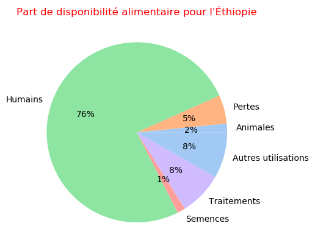

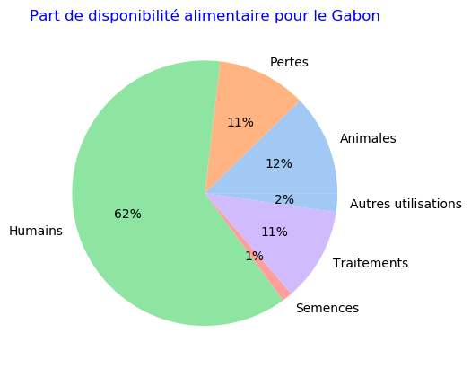

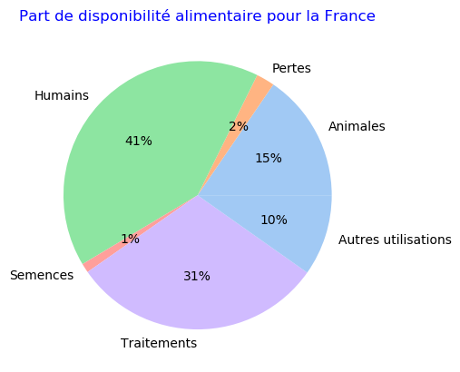

```python
#define data for Éthiopie
data = [calc_part_animale_ethiopie, calc_perte_ethiopie, calc_part_humain_ethiopie, calc_part_semence_ethiopie, calc_part_traitement_ethiopie, calc_part_autre_utilisation_ethiopie]
labels = ['Animales', 'Pertes', 'Humains', 'Semences', 'Traitements', 'Autres utilisations']

#define Seaborn color palette to use
colors = sns.color_palette('pastel')[0:5]

#create pie chart
plt.pie(data, labels = labels, colors = colors, autopct='%.0f%%')
plt.title("Part de disponibilité alimentaire pour l'Éthiopie",color='r')

plt.show()

#define data fore Gabon
data = [calc_part_animale_gabon, calc_perte_gabon, calc_part_humain_gabon, calc_part_semence_gabon, calc_part_traitement_gabon, calc_part_autre_utilisation_gabon]
labels = ['Animales', 'Pertes', 'Humains', 'Semences', 'Traitements', 'Autres utilisations']

#define Seaborn color palette to use
colors = sns.color_palette('pastel')[0:5]

#create pie chart
plt.pie(data, labels = labels, colors = colors, autopct='%.0f%%')
plt.title("Part de disponibilité alimentaire pour le Gabon",color='b')

plt.show()

#define data for France
data = [calc_part_animale_france, calc_perte_france, calc_part_humain_france, calc_part_semence_france, calc_part_traitement_france, calc_part_autre_utilisation_france]
labels = ['Animales', 'Pertes', 'Humains', 'Semences', 'Traitements', 'Autres utilisations']

#define Seaborn color palette to use
colors = sns.color_palette('pastel')[0:5]

#create pie chart
plt.pie(data, labels = labels, colors = colors, autopct='%.0f%%')
plt.title("Part de disponibilité alimentaire pour la France",color='b')

plt.show()
```

### Conclusion

Retour au sommaire

Le changement climatique, la COVID-19, les guerres et le manque de coopération sont autant de facteurs qui contribuent à la crise alimentaire mondiale.  
Il est important de rappeler que la plupart des personnes sous-alimentées dans le monde vivent dans les pays en développement, où les catastrophes naturelles ont un impact plus important.

Au vu des chiffres, il est clair que malgré les améliorations de la sécurité alimentaire dans de nombreuses régions, d'énormes problèmes subsistent.  
Par exemple les aides alimentaire ne sont pas bien distribuées:

[figure not shown]

Les principales victimes de la faim et de la malnutrition sont les femmes et les enfants. Les chiffres concernant les enfants et les adolescents sous-alimentés sont encore plus alarmants. L'Unicef révèle que chaque jour, près de 6 millions de jeunes de moins de 5 ans meurent de maladies causées par le manque de nourriture.